# Suzuki T2D

This vignette asks whether gpmapr’s univariate SNP programs recover the mechanistic clusters of type 2 diabetes (T2D) signals that Suzuki et al. (2024) defined. The analysis runs on the European-ancestry meta-analysis from that paper, uploaded to GPMap. The questions are:

- Which programs pass validation? Only high and medium confidence programs are compared with Suzuki’s clusters.
- Do a program’s member SNPs match the index SNVs of a Suzuki cluster?
- Does its profile over Suzuki’s cardiometabolic traits match the cluster’s?
- Does it carry that cluster’s canonical genes?

The program summary cards in Part 4 bring these together, and Part 4 ends with a hand-written match of each program to Suzuki’s clusters.

## Part 1: Suzuki et al. (2024)

> Suzuki K, Hatzikotoulas K, Southam L, *et al.* Genetic drivers of heterogeneity in type 2 diabetes pathophysiology. *Nature* 627, 347–357 (2024). https://doi.org/10.1038/s41586-024-07019-6

The reference tables used below are CC BY 4.0 extracts of the paper’s supplementary material. They are in `inst/extdata/suzuki2024/` and are regenerated by `data-raw/suzuki2024.R`.

### Study

- **Scale.** The Type 2 Diabetes Global Genomics Initiative meta-analysed 428,452 T2D cases and 2,107,149 controls across six ancestry groups.
- **Discovery.** Signals come from multi-ancestry meta-regression (MR-MEGA) with three axes of genetic variation as covariates.
  - Index SNVs were selected at *P* < 5 × 10⁻⁸ by greedy clumping. A variant joined a clump if r² > 0.05 with the index SNV in *any* of the five 1000 Genomes super-populations, within 5 Mb.
  - This gave **1,289 independent signals at 611 loci**, of which 145 loci are new.
- **EUR meta-analysis (the dataset used here).**
  - 36 GWAS: 242,283 cases and 1,569,734 controls (effective N ≈ 751,755, 60.3% of the total).
  - Fixed-effects inverse-variance meta-analysis in METAL, GRCh37.
  - The largest contributors are the Million Veteran Program (90,107 cases), FinnGen (37,002), UK Biobank (19,119), the Estonian Biobank (12,208) and deCODE (11,448). 23andMe is not included.
- **Signal sets differ.** The 1,289 signals were discovered in the multi-ancestry analysis, so some are driven by non-European data and may be weak or absent in the EUR upload.

### How the clusters were built

1. **Inputs.** Each index SNV’s associations with 37 cardiometabolic traits were taken from the largest available GWAS (Supplementary Table 5) and aligned to the T2D risk allele.
2. **Scaling.** Each association was scaled as $Z_{ij} = \beta_{ij} / (\sqrt{N_i}\, s_{ij})$, which is a standardised per-allele effect that does not depend on the trait GWAS’s size.
3. **Clustering.** The SNVs were grouped by k-means with iterative imputation of missing associations (ClustImpute). The number of clusters came from the majority rule over 27 NbClust indices.
4. **Hard assignment.** Every SNV is assigned to exactly one cluster. This differs from earlier soft clustering by Bayesian non-negative matrix factorisation (Udler *et al.* 2018), which gives each SNV cluster weights and leaves some unassigned.

The eight mechanistic clusters (main-text Table 1, Supplementary Table 9, Fig. 2). * = trait adjusted for BMI. t2d_or is the inverse-variance weighted mean T2D odds ratio of the cluster’s index SNVs. Insulin secretion/sensitivity give the direction of the T2D risk allele’s effect.

| cluster | n_signals | new_in_suzuki | cardiometabolic_profile | example_loci | insulin_secretion | insulin_sensitivity | t2d_or | open_chromatin_enrichment |
| --- | --- | --- | --- | --- | --- | --- | --- | --- |
| Beta cell +PI | 91 | no | +FG*, +2hG*, +HbA1c, +PI* | TCF7L2; KCNQ1; CDKAL1; CDKN2A-CDKN2B; SLC30A8 | - | + | 1.022 | Fetal islets; adult islet alpha/beta/gamma/delta cells |
| Beta cell -PI | 89 | no | +FG*, +2hG*, +HbA1c, -PI* | CDC123-CAMK1D; HNF1B; KCNJ11-ABCC8; HNF4A; HNF1A | - | + | 1.016 | Fetal islets; adult islet endocrine cells; adult enterochromaffin cells |
| Residual glycaemic | 389 | yes | +FG*, +HbA1c | GCC1-PAX4-LEP; ANKRD55; GCKR; UBE2E2 | - | - | 1.012 | Fetal islets; adult islet endocrine cells; fetal and adult pancreatic ductal cells |
| Body fat | 273 | yes | +Body fat, +ASAT* | ZMIZ1; HMGA2; CTBP1 | + | - | 1.011 | None |
| Metabolic syndrome | 166 | yes | +FG*, +FI*, +WHR, +VAT*, -GFAT*, +TG, -HDL, +BP | IGF2BP2; CCND2; HHEX-IDE; JAZF1; GPSM1 | + | - | 1.013 | Adult pericytes; fetal endothelial cells; fetal mesangial cells; fetal fibroblasts; brain IT and SST+ neurons |
| Obesity | 233 | no | +BMI, +WHR, +body fat, +BMR, +TG, -HDL | FTO; MC4R; MACF1; TMEM18 | + | - | 1.012 | Adult islet alpha/gamma/delta cells; fetal adrenal, heart and kidney cells; brain IT, SST+ and D1 medium spiny neurons |
| Lipodystrophy | 45 | no | +FI*, +WHR, -body fat, -GFAT*, +TG, -HDL, +BP | IRS1; GRB14-COBLL1; PPARG | + | - | 1.015 | Adult adipocytes |
| Liver/lipid metabolism | 3 | no | -LDL, -TC, +liver fat, +liver biomarkers | TOMM40-APOE-GIPR; TM6SF2; PNPLA3 | - | - | 1.020 | Not estimated (3 signals) |

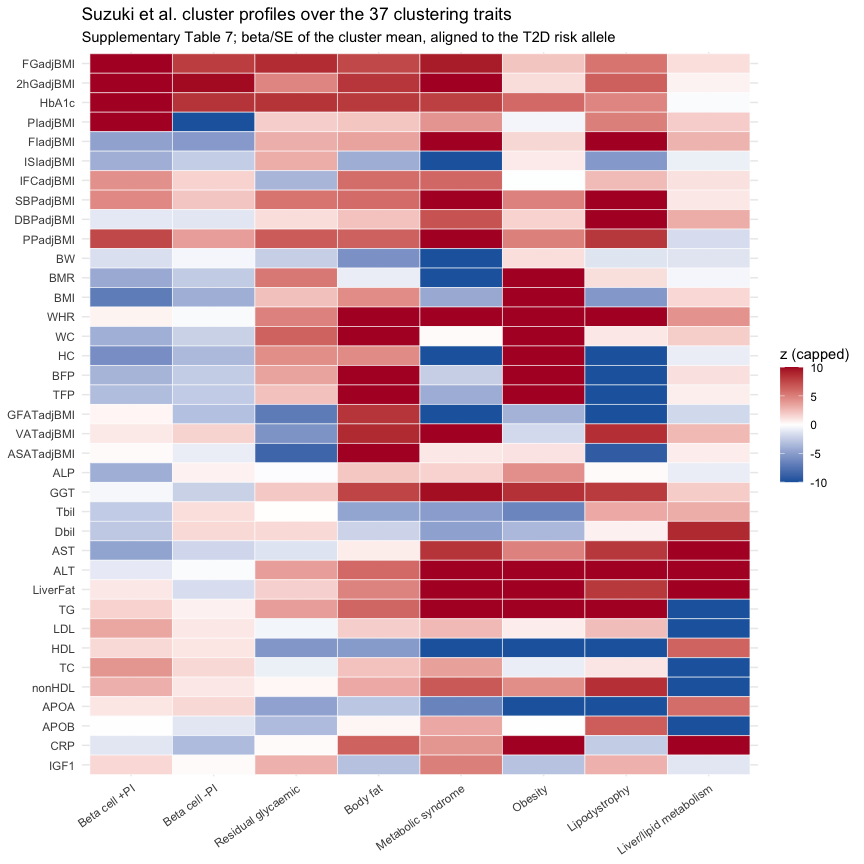

### How the paper validated the clusters

- **Physiology.** The clusters form a cline in insulin-related measures (HOMA-B, HOMA-IR, clamp-derived sensitivity). It runs from low insulin secretion in the two beta-cell clusters to the most extreme insulin resistance in the Lipodystrophy cluster.
- **Single-cell open chromatin.** The clusters are enriched for different cell types:
  - beta-cell and Residual glycaemic clusters: pancreatic islets;
  - Beta cell −PI: also enterochromaffin cells;
  - Lipodystrophy: adipocytes only;
  - Metabolic syndrome: pericytes and endothelial cells;
  - Obesity: islet non-beta cells, adrenal and brain neurons;
  - Body fat: no enrichment.
- **Partitioned polygenic scores.** After adjusting for the overall T2D score:
  - the Obesity score is associated with higher risk of coronary artery disease, peripheral artery disease, end-stage diabetic nephropathy and earlier T2D onset;
  - the Beta cell +PI score is associated with *lower* coronary artery disease and nephropathy risk.

## Part 2: The uploaded GWAS

Upload metadata. n_signals counts the upload’s own fine-mapped signals (distinct lead variants) at each threshold. Suzuki et al. used 5e-8.

| name | guid | sample_size | ancestry | reference_build | upload_p_threshold | status | n_coloc_groups | n_signals_p5e6 | n_signals_p5e8 |
| --- | --- | --- | --- | --- | --- | --- | --- | --- | --- |
| 2DGGI GWAS EUR ancestry meta-analysis | c6d2e20f-6ece-d093-78ee-37534547c466 | 1812017 | EUR | GRCh37 | 5e-06 | completed | 534 | 534 | 498 |

The analysis below uses signals at the upload’s own threshold. Re-render with `params = list(p_threshold = 5e-8)` to match the genome-wide threshold that Suzuki et al. used.

## Part 3: Univariate analysis

The steps are the same as in the univariate analysis investigation, except that T2D proxy traits are removed first (see below):

1. Build a pleiotropy matrix of z-scores (`beta / se`) for every background trait at each upload SNP, keeping phenotypic traits only and leaving out the T2D proxy traits.
2. Drop sparse traits (observed at fewer than `min_snp_signals` SNPs) and ubiquitous traits (observed at more than 80% of SNPs).
3. Orient every SNP to the T2D risk allele and compress with asinh.
4. Factorise with EBMF into overlapping programs.
5. Validate the programs.

Shared settings come from `vignettes/_ebmf_settings.yml`. After validation, each program is annotated as in that vignette, in one table:

- module-specific traits;
- loading-based (continuous) enrichment of trait categories, tissues and pathways;
- the genes at the program’s SNPs, which this vignette adds (shown in the program summary cards).

Only the pleiotropy comparison of unique vs shared SNPs is left to the univariate vignette.

Active run parameters

| api | gpmap_url | target_guid | p_threshold | associations | trait_subset | include_trans | min_snp_signals | compress_method | compress_scale | ebmf_prior | ebmf_backfit | ebmf_lfsr_threshold | ebmf_magnitude_threshold | ebmf_greedy_Kmax | min_module_size | similarity_threshold | similarity_n_perm | similarity_q | high_similarity_q | high_connectedness | min_effective_traits | n_rep | frac_traits | redundancy_threshold |
| --- | --- | --- | --- | --- | --- | --- | --- | --- | --- | --- | --- | --- | --- | --- | --- | --- | --- | --- | --- | --- | --- | --- | --- | --- |
| production | https://gpmap.opengwas.io/api | c6d2e20f-6ece-d093-78ee-37534547c466 | upload default | coloc | phenotypic | TRUE | 2 | asinh | 5 | point_laplace | TRUE | 0.02 | 0.75 | 100 | 3 | 0.2 | 10000 | 0.05 | 0.01 | 0.4 | 1.5 | 3 | 0.8 | 0.9 |

### T2D proxy traits

GPMap holds several other GWAS of T2D itself, or of traits defined by having diabetes. At risk-oriented T2D SNPs they all repeat the anchor trait, so they add no information about mechanism. They can also give EBMF extra weight to spend on small differences between near-identical rows. They are removed from the matrix before fitting.

The list was drawn up by searching `all_traits()` and the upload’s coloc partners for diabetes-related names, then pruned by hand. It covers:

- **T2D GWAS:** GPMap’s own T2D and the UK Biobank SPA/Firth versions.
- **Diagnosis:** doctor-diagnosed, self-reported and ICD10 E11.9 diabetes.
- **Treatment:** diabetes medication, metformin, gliclazide and insulin.
- **Family history:** diabetes in the mother, father or siblings.
- **Complications:** diabetes-related eye disease.

Kept on purpose:

- **Glycaemic traits** (glucose, HbA1c, insulin and proinsulin), which are Suzuki clustering traits.
- **Type 1 diabetes**, a distinct disease.
- **Combined medication fields**, such as “Medication for cholesterol, blood pressure or diabetes: Blood pressure medication”.

T2D proxy traits removed before building the matrix. n_coloc_groups = the upload’s coloc groups that each trait shares.

| trait_id | trait_name | group | n_coloc_groups |
| --- | --- | --- | --- |
| 114 | Type 2 diabetes | T2D GWAS | 49 |
| 2499 | Type 2 diabetes (Firth correction) | T2D GWAS | 21 |
| 2549 | Type 2 diabetes (SPA correction) | T2D GWAS | 22 |
| 2863 | Diabetes diagnosed by doctor | Diagnosis | 36 |
| 3106 | Non-cancer illness code, self-reported: diabetes | Diagnosis | 28 |
| 4536 | Diagnoses - secondary ICD10: E11.9 Without complications | Diagnosis | 13 |
| 1494 | Medication use (drugs used in diabetes) | Treatment | 47 |
| 3270 | Treatment/medication code: metformin | Treatment | 22 |
| 4422 | Treatment/medication code: gliclazide | Treatment | 4 |
| 3333 | Treatment/medication code: insulin product | Treatment | 2 |
| 4300 | Medication for cholesterol, blood pressure or diabetes: Insulin | Treatment | 1 |
| 4403 | Started insulin within one year diagnosis of diabetes | Treatment | 3 |
| 3428 | Illnesses of mother: Diabetes | Family history | 7 |
| 3779 | Illnesses of father: Diabetes | Family history | 9 |
| 3580 | Illnesses of siblings: Diabetes | Family history | 5 |
| 2814 | Eye problems/disorders: Diabetes related eye disease | Complication | 2 |

### Fit

Pleiotropy matrix after filtering, and the EBMF fit

| n_traits | n_phenotypic | n_traits_dropped | n_snps | fraction_non_na | n_ebmf_factors | dropped_global_factors | greedy_Kmax_reached |
| --- | --- | --- | --- | --- | --- | --- | --- |
| 657 | 657 | 8026 | 528 | 0.025 | 54 | 0 | FALSE |

### Program confidence

`summarise_ebmf_programs()` drops programs with fewer than `min_module_size` member SNPs and gives every other program a **confidence tier**. Every kept program is annotated in Part 3, whatever its tier; Part 4 compares only the high and medium programs with Suzuki’s clusters.

Member SNPs are those passing the lFSR/magnitude cut. `S` is the cosine similarity between two SNPs’ oriented, compressed profiles across the background traits, with missing cells counted as 0 and the T2D row left out (it is positive at every SNP, so it would add the same similarity to every pair).

- **low** — `similarity_q >= similarity_q`: the member SNPs are no more alike than random SNP groups of the same size. This is checked first, so a program that fails it is low whatever its number of traits, and can be set aside.
- **single_trait** — passes the similarity test, but the program’s trait loadings rest on fewer than `min_effective_traits` effective traits. A program is defined as multi-trait: a factor carried by one trait is just that trait’s hits, which noise produces too, so it needs a closer look rather than being discarded.
- **high** — `similarity_q < high_similarity_q` and `connectedness >= high_connectedness`.
- **medium** — `similarity_q < similarity_q`, but not high.

The columns:

- **effective_n_traits**: `1 / sum(p^2)`, where `p` are the program’s squared trait loadings as shares of their total (T2D row left out): 1 for a program on one trait, `n` for `n` equally loaded traits.
- **mean_internal_similarity** and **similarity_q**: the mean `S` between pairs of member SNPs, and the BH-adjusted share of random groups of the same number of T2D SNPs that are at least as similar. A significance test, so larger programs pass more easily.
- **connectedness**: the share of member pairs with `S >= similarity_threshold`.
- **excess_similarity** and **excess_connectedness** (reported): each of the above minus its value in the random groups; effect sizes that do not grow with program size.
- **factor_pve_pct** (reported): the share of the matrix variance the factor explains.
- **replication** (reported): the mean Jaccard overlap between the program’s top SNPs and the best-matching factor when 20% of the background traits are held out and EBMF is refit.
- **parent_program**: when at least 90% of a program’s SNPs sit at the loci of a larger program, that program is its parent. Sub-programs are kept and listed under their parent.

Every EBMF program by confidence tier (green high, orange medium, grey single trait, red low), each child program indented under its parent.

| program | confidence_tier | n_snps_filtered | effective_n_traits | mean_internal_similarity | excess_similarity | connectedness | excess_connectedness | similarity_q | factor_pve_pct | replication | parent_program |
| --- | --- | --- | --- | --- | --- | --- | --- | --- | --- | --- | --- |
| 1 | high | 71 | 28.64 | 0.313 | 0.283 | 0.683 | 0.607 | 0.00073 | 7.97 | 0.77 | NA |
| 11 | high | 27 | 5.50 | 0.441 | 0.412 | 0.741 | 0.665 | 0.00073 | 0.85 | 0.87 | NA |
| 49 | high | 14 | 2.28 | 0.338 | 0.308 | 0.495 | 0.418 | 0.00073 | 0.17 | 0.34 | NA |
| 6 | high | 25 | 20.96 | 0.193 | 0.163 | 0.507 | 0.431 | 0.00073 | 1.22 | 0.41 | NA |
| 2 | high | 9 | 100.45 | 0.341 | 0.311 | 0.778 | 0.702 | 0.00088 | 7.06 | 1.00 | NA |
| ↳ 33 | high | 4 | 42.15 | 0.728 | 0.698 | 1.000 | 0.924 | 0.00088 | 0.79 | 1.00 | 2 |
| ↳ 36 | high | 3 | 63.29 | 0.673 | 0.643 | 1.000 | 0.925 | 0.00270 | 0.39 | 0.43 | 33 |
| 54 | high | 6 | 14.99 | 0.372 | 0.342 | 0.800 | 0.724 | 0.00220 | 0.13 | 0.25 | NA |
| 44 | high | 25 | 5.12 | 0.145 | 0.115 | 0.410 | 0.334 | 0.00088 | 0.17 | 0.22 | NA |
| 40 | high | 3 | 12.82 | 0.520 | 0.490 | 1.000 | 0.925 | 0.00660 | 0.21 | 0.76 | NA |
| 22 | high | 10 | 4.47 | 0.191 | 0.161 | 0.489 | 0.412 | 0.00270 | 0.30 | 0.37 | NA |
| 50 | medium | 24 | 2.36 | 0.204 | 0.174 | 0.399 | 0.322 | 0.00073 | 0.36 | 0.60 | NA |
| 16 | medium | 46 | 5.51 | 0.120 | 0.090 | 0.382 | 0.306 | 0.00073 | 0.90 | 0.44 | NA |
| 4 | medium | 68 | 23.19 | 0.081 | 0.051 | 0.349 | 0.273 | 0.00088 | 1.48 | 0.63 | NA |
| 13 | medium | 27 | 6.03 | 0.112 | 0.083 | 0.293 | 0.218 | 0.00120 | 0.64 | 0.69 | NA |
| 31 | medium | 28 | 2.68 | 0.099 | 0.070 | 0.222 | 0.147 | 0.00270 | 0.30 | 0.41 | NA |
| 10 | medium | 24 | 7.02 | 0.104 | 0.074 | 0.330 | 0.253 | 0.00280 | 0.56 | 0.75 | NA |
| 26 | medium | 6 | 20.33 | 0.226 | 0.196 | 0.600 | 0.524 | 0.01200 | 0.31 | 0.62 | NA |
| 35 | medium | 32 | 5.07 | 0.083 | 0.053 | 0.242 | 0.166 | 0.00610 | 0.58 | 0.49 | NA |
| 24 | medium | 25 | 2.50 | 0.091 | 0.061 | 0.213 | 0.138 | 0.00690 | 0.42 | 0.56 | NA |
| 53 | medium | 7 | 55.64 | 0.159 | 0.130 | 0.286 | 0.211 | 0.02100 | 0.46 | 0.25 | NA |
| 17 | medium | 3 | 58.63 | 0.287 | 0.257 | 0.333 | 0.258 | 0.02900 | 0.83 | 0.58 | NA |
| 45 | medium | 11 | 7.41 | 0.106 | 0.076 | 0.236 | 0.160 | 0.03200 | 0.22 | 0.55 | NA |
| 47 | medium | 34 | 2.81 | 0.064 | 0.035 | 0.169 | 0.094 | 0.02900 | 0.36 | 0.46 | NA |
| 14 | single_trait | 3 | 1.00 | 0.670 | 0.640 | 1.000 | 0.925 | 0.00270 | 0.46 | 0.26 | NA |
| 3 | single_trait | 29 | 1.45 | 0.086 | 0.056 | 0.175 | 0.099 | 0.00660 | 2.15 | 0.18 | NA |
| 28 | low | 6 | 7.43 | 0.123 | 0.093 | 0.533 | 0.458 | 0.06500 | 0.25 | 0.83 | NA |
| 41 | low | 13 | 2.99 | 0.079 | 0.049 | 0.321 | 0.245 | 0.06900 | 0.19 | 0.74 | NA |
| 8 | low | 4 | 62.73 | 0.144 | 0.113 | 0.500 | 0.424 | 0.07300 | 0.75 | 0.50 | NA |
| 52 | low | 21 | 2.23 | 0.057 | 0.027 | 0.195 | 0.120 | 0.11000 | 0.29 | 0.57 | NA |
| 23 | low | 13 | 7.24 | 0.046 | 0.016 | 0.308 | 0.232 | 0.29000 | 0.40 | 0.62 | NA |
| 25 | low | 36 | 3.94 | 0.035 | 0.006 | 0.313 | 0.237 | 0.37000 | 0.90 | 0.56 | NA |
| 19 | low | 13 | 6.06 | 0.040 | 0.010 | 0.179 | 0.104 | 0.37000 | 0.32 | 0.40 | NA |
| 12 | low | 14 | 12.59 | 0.037 | 0.007 | 0.187 | 0.110 | 0.40000 | 0.47 | 0.81 | NA |
| 15 | low | 25 | 7.92 | 0.033 | 0.003 | 0.143 | 0.068 | 0.45000 | 0.68 | 0.74 | NA |
| 27 | low | 13 | 9.28 | 0.031 | 0.001 | 0.167 | 0.091 | 0.49000 | 0.22 | 0.70 | NA |
| 30 | low | 10 | 4.70 | 0.030 | 0.000 | 0.200 | 0.124 | 0.49000 | 0.20 | 0.72 | NA |
| 20 | low | 14 | 8.22 | 0.028 | -0.001 | 0.176 | 0.099 | 0.52000 | 0.27 | 0.74 | NA |
| 43 | low | 16 | 3.18 | 0.025 | -0.005 | 0.167 | 0.091 | 0.58000 | 0.25 | 0.74 | NA |
| 34 | low | 6 | 1.00 | 0.019 | -0.011 | 0.467 | 0.391 | 0.58000 | 0.22 | 0.35 | NA |
| 21 | low | 9 | 9.75 | 0.019 | -0.011 | 0.056 | -0.020 | 0.62000 | 0.29 | 0.80 | NA |
| 46 | low | 20 | 10.75 | 0.014 | -0.015 | 0.258 | 0.183 | 0.85000 | 0.19 | 0.24 | NA |
| 7 | low | 15 | 7.89 | 0.007 | -0.023 | 0.124 | 0.048 | 0.91000 | 0.41 | 0.53 | NA |
| 48 | low | 17 | 4.15 | -0.005 | -0.034 | 0.132 | 0.057 | 0.99000 | 0.28 | 0.28 | NA |

Program confidence summary. n_dropped_small = programs below min_module_size, removed before any check. T2D background: mean S = 0.03, share of SNP pairs with S >= 0.2 = 0.076.

| n_programs | n_high | n_medium | n_single_trait | n_low | n_dropped_small | n_snps | n_snps_in_analysed_programs |
| --- | --- | --- | --- | --- | --- | --- | --- |
| 44 | 11 | 13 | 2 | 18 | 10 | 528 | 290 |

### Module-specific traits and loading-based enrichment

One row per analysed program, in confidence order (green high, orange medium, grey single trait, red low), with each child program indented under its parent. The columns come from two analyses.

**Module-specific traits.** The background traits most elevated in the program relative to the rest of the T2D SNPs: `specificity = mean |z| in program / (mean |z| elsewhere + 0.1)`, shown in brackets. Traits need a specificity of at least 1.25, and the top 8 are listed.

**Loading-based enrichment** of trait categories, tissues and pathways (KEGG and Reactome, on the colocalising QTL genes). There is no membership cutoff: every SNP contributes to every program, weighted by its squared EBMF loading, in the regression `lm(loading^2 ~ membership)`. A hit needs both FDR ≤ 0.05 and R² ≥ 0.05. The FDR is computed across every program tested, separately for categories, tissues and pathways.

**Tissues differ from Suzuki’s.** GPMap’s tissues are GTEx-style bulk tissues. “Pancreas” is bulk GTEx pancreas, mostly exocrine, and there are no islets. Suzuki’s islet-cell enrichments therefore have no direct counterpart here.

Module-specific traits (specificity in brackets) and loading-based enrichment (FDR <= 0.05 and R2 >= 0.05) for every analysed program, by confidence tier.

| program | n_snps | module_specific_traits | trait_categories | tissues | reactome | kegg |
| --- | --- | --- | --- | --- | --- | --- |
| 1 | 71 | Qualifications: A levels/AS levels or equivalent (1.7) Apolipoprotein B levels (1.55) Intelligence (1.52) Blood urea nitrogen levels (1.45) Basal metabolic rate (1.39) Body mass index (UKB data field … | Reproductive Measures (effect=1.8, R2=0.1, FDR=2.04e-12) Behavioural Measures (effect=1.1, R2=0.062, FDR=2.57e-07) Anthropometric Measures (effect=0.86, R2=0.094, FDR=3.66e-11) | none | none | none |
| 11 | 27 | Impedance of arm (left) (1.4) Impedance of arm (right) (1.4) Glycated haemoglobin HbA1c levels (UKB data field 30750) (1.3) Blood glucose levels (1.29) Haemoglobin A1c levels (1.28) | none | none | none | Protein processing in endoplasmic reticulum (effect=1, R2=0.082, FDR=2.58e-09) |
| 49 | 14 | Comparative body size at age 10 (1.42) Impedance of leg (right) (1.38) Body mass index (BMI) (1.35) Body mass index (1.35) Weight (1.35) Menarche (age at onset) (1.33) Body mass index (UKB data field … | Reproductive Measures (effect=0.85, R2=0.24, FDR=9.73e-31) | none | none | none |
| 6 | 25 | Heel bone mineral density (1.4) Sex hormone-binding globulin levels adjusted for BMI (1.37) Leg fat-free mass (left) (1.35) HDL cholesterol levels (1.33) Sex hormone-binding globulin levels (1.3) Weig… | Reproductive Measures (effect=2.5, R2=0.059, FDR=6.46e-07) | none | none | none |
| 2 | 9 | Cholesteryl esters to total lipids ratio in very large VLDL (2.13) Cholesterol to total lipids ratio in very large VLDL (1.91) Triglyceride levels (1.89) Phospholipids to total lipids ratio in small L… | Metabolic Disease (effect=6.7, R2=0.16, FDR=1.53e-19) | none | none | Cholesterol metabolism (effect=9.7, R2=0.052, FDR=6.82e-06) |
| ↳ 33 | 4 | Triglyceride levels (1.66) HDL cholesterol levels (1.61) Triglyceride levels (UKB data field 30870) (1.59) Triglycerides (1.55) High density lipoprotein cholesterol levels (UKB data field 30760) (1.54… | Metabolic Disease (effect=1.3, R2=0.094, FDR=3.66e-11) Disease Of Circulatory System (effect=0.72, R2=0.05, FDR=5.07e-06) | none | none | none |
| ↳ 36 | 3 | none | none | none | none | none |
| 54 | 6 | High density lipoprotein cholesterol levels (UKB data field 30760) (1.57) Triglyceride levels (1.52) Triglyceride levels (UKB data field 30870) (1.4) Apolipoprotein A levels (UKB data field 30630) (1.… | none | none | Class I MHC mediated antigen processing & presentation (effect=3.1, R2=0.18, FDR=6.03e-22) SARS-CoV-2 Infection (effect=3.1, R2=0.18, FDR=6.03e-22) Interferon gamma signaling (effect=2.5, R2=0.15, FDR… | none |
| 44 | 25 | C-reactive protein levels (1.67) C-reactive protein (1.54) Trunk fat-free mass (1.49) Trunk predicted mass (1.48) Whole body water mass (1.32) Overall health rating (1.28) | Socioeconomic Measures (effect=0.35, R2=0.054, FDR=2.27e-06) Anthropometric Measures (effect=0.13, R2=0.052, FDR=2.9e-06) | none | none | none |
| 40 | 3 | none | Infectious Disease (effect=3.7, R2=0.21, FDR=6e-26) Neurological Disease (effect=2.4, R2=0.087, FDR=2.08e-10) | none | TCR signaling (effect=6.7, R2=0.38, FDR=1.45e-52) Generation of second messenger molecules (effect=6.7, R2=0.38, FDR=1.45e-52) Costimulation by the CD28 family (effect=6.7, R2=0.38, FDR=1.45e-52) Inte… | Th17 cell differentiation (effect=6.7, R2=0.38, FDR=1.45e-52) Influenza A (effect=5.6, R2=0.31, FDR=9.18e-42) Viral myocarditis (effect=5.6, R2=0.31, FDR=9.18e-42) Th1 and Th2 cell differentiation (ef… |
| 22 | 10 | C-reactive protein levels (1.38) Arm fat percentage (left) (1.29) Leg fat percentage (left) (1.26) | Neurological Disease (effect=3.7, R2=0.11, FDR=5.22e-13) | Plasma (effect=1.9, R2=0.057, FDR=2.15e-05) | Vesicle-mediated transport (effect=6.7, R2=0.2, FDR=5.5e-24) Signaling by Nuclear Receptors (effect=4.9, R2=0.14, FDR=4.93e-17) Signaling by Receptor Tyrosine Kinases (effect=4.2, R2=0.12, FDR=4.45e-1… | Cholesterol metabolism (effect=6.7, R2=0.2, FDR=5.5e-24) Mitophagy - animal (effect=5.7, R2=0.17, FDR=1.23e-20) Tight junction (effect=4.8, R2=0.14, FDR=1.86e-16) Amyotrophic lateral sclerosis (effect… |
| 50 | 24 | Triglyceride levels (1.69) Gamma glutamyl transpeptidase (1.51) Gamma glutamyltransferase levels (UKB data field 30730) (1.45) Triglycerides to total lipids ratio in very small VLDL (1.31) Cholesteryl… | none | none | none | none |
| 16 | 46 | Red cell distribution width (1.81) Calcium levels (UKB data field 30680) (1.43) Pulse rate, automated reading (1.42) Impedance of whole body (1.37) Leg predicted mass (right) (1.32) Comparative body s… | Reproductive Measures (effect=1.6, R2=0.13, FDR=1.82e-15) Anthropometric Measures (effect=0.59, R2=0.069, FDR=3.75e-08) | none | none | none |
| 4 | 68 | Qualifications: A levels/AS levels or equivalent (1.54) Sitting height (1.46) Triglyceride levels (1.4) C-reactive protein (1.4) Appendicular lean mass (1.39) Cholesteryl esters to total lipids ratio … | Anthropometric Measures (effect=0.58, R2=0.095, FDR=2.74e-11) | none | none | none |
| 13 | 27 | Alcohol intake frequency. (1.54) Low density lipoprotein cholesterol levels (1.51) Pulse pressure (1.45) Arm predicted mass (left) (1.38) Triglyceride levels (1.37) Impedance of arm (left) (1.36) Arm … | Disease Of Circulatory System (effect=2.4, R2=0.27, FDR=2.88e-35) Metabolic Disease (effect=1.9, R2=0.1, FDR=2.04e-12) | none | Class A/1 (Rhodopsin-like receptors) (effect=3.2, R2=0.055, FDR=3.22e-06) G alpha (s) signalling events (effect=3, R2=0.061, FDR=6.1e-07) | Neuroactive ligand signaling (effect=3.9, R2=0.068, FDR=1.03e-07) Dilated cardiomyopathy (effect=3.9, R2=0.068, FDR=1.03e-07) Cadherin signaling (effect=3.9, R2=0.094, FDR=8.36e-11) Kaposi sarcoma-ass… |
| 31 | 28 | High blood pressure (UKB data field 6150) (Firth correction) (1.33) High blood pressure (UKB data field 6150) (SPA correction) (1.33) Impedance of arm (right) (1.32) Sex hormone-binding globulin level… | none | none | none | none |
| 10 | 24 | Mean corpuscular haemoglobin (1.64) Triglyceride levels (1.54) Reticulocyte count (1.49) Eosinophil percentage of white cells (1.45) Eosinophill percentage (1.37) Cholesterol to total lipids ratio in … | none | none | none | TGF-beta signaling pathway (effect=5.1, R2=0.061, FDR=6.72e-07) |
| 26 | 6 | HDL cholesterol (1.26) Triglyceride levels (1.26) | none | Kidney Cortex (effect=3, R2=0.062, FDR=1.06e-05) Brain Amygdala (effect=2.6, R2=0.052, FDR=6.79e-05) | none | Non-small cell lung cancer (effect=9.5, R2=0.13, FDR=3.59e-15) Chronic myeloid leukemia (effect=7.9, R2=0.11, FDR=2.08e-12) Melanoma (effect=6.7, R2=0.091, FDR=1.79e-10) Glioma (effect=6.7, R2=0.091, … |
| 35 | 32 | Mean platelet volume (1.75) Sex hormone-binding globulin levels adjusted for BMI (1.48) Red cell distribution width (1.44) Appendicular lean mass (1.42) Alanine aminotransferase levels (1.38) Impedanc… | none | Liver (effect=0.91, R2=0.058, FDR=1.88e-05) | Signaling by NOTCH (effect=2.8, R2=0.089, FDR=3.33e-10) Diseases of signal transduction by growth factor receptors and second messengers (effect=2.2, R2=0.054, FDR=5.06e-06) | Cytokine-cytokine receptor interaction (effect=2.4, R2=0.065, FDR=2.58e-07) |
| 24 | 25 | Leg fat-free mass (left) (1.35) Heel bone mineral density (1.31) | none | none | none | none |
| 53 | 7 | High density lipoprotein cholesterol levels (UKB data field 30760) (1.67) HDL cholesterol (1.63) HDL cholesterol levels (1.62) Mean corpuscular haemoglobin (1.58) Red cell distribution width (1.35) Im… | Disease Of Musculoskeletal System And Connective Tissue (effect=3.6, R2=0.053, FDR=2.53e-06) | none | Signaling by NOTCH (effect=11, R2=0.16, FDR=1.03e-19) Diseases of signal transduction by growth factor receptors and second messengers (effect=11, R2=0.16, FDR=1.03e-19) | Cytokine-cytokine receptor interaction (effect=11, R2=0.16, FDR=1.03e-19) Notch signaling pathway (effect=8.2, R2=0.12, FDR=3.15e-14) TGF-beta signaling pathway (effect=6.6, R2=0.099, FDR=2.13e-11) Hi… |
| 17 | 3 | Triglyceride levels (UKB data field 30870) (1.57) | none | Plasma (effect=7.8, R2=0.051, FDR=7.4e-05) | none | Cholesterol metabolism (effect=29, R2=0.2, FDR=2.65e-24) |
| 45 | 11 | Lung function (FEV1/FVC) (2.08) Appendicular lean mass (1.52) FEV1 (1.4) Sitting height (1.37) Lung function (FVC) (1.33) Trunk fat-free mass (1.3) Trunk predicted mass (1.3) Forced expiratory volume … | none | none | none | none |
| 47 | 34 | Red cell distribution width (1.58) IGF 1 (UKB data field 30770) (1.46) Aspartate aminotransferase levels (1.46) Red blood cell (erythrocyte) distribution width (1.36) Leg fat percentage (left) (1.35) … | none | none | RHO GTPase cycle (effect=4, R2=0.089, FDR=3.27e-10) | Mitophagy - animal (effect=3, R2=0.063, FDR=4.12e-07) |
| 14 | 3 | none | none | none | none | none |
| 3 | 29 | Fasting glucose (1.4) | none | none | none | none |
| 28 | 6 | Qualifications: None of the above (1.49) Qualifications: College or University degree (1.42) Qualifications: A levels/AS levels or equivalent (1.36) | Socioeconomic Measures (effect=2.3, R2=0.14, FDR=6.06e-17) Psychiatric Measures (effect=1.2, R2=0.057, FDR=8.96e-07) | none | none | none |
| 41 | 13 | Arm predicted mass (right) (1.62) Leg fat mass (left) (1.5) Leg predicted mass (right) (1.49) Leg fat-free mass (right) (1.49) Whole body fat-free mass (1.47) Whole body water mass (1.46) Arm predicte… | Disease Of Circulatory System (effect=0.44, R2=0.055, FDR=1.63e-06) | none | none | Non-small cell lung cancer (effect=1.8, R2=0.087, FDR=5.28e-10) Chronic myeloid leukemia (effect=1.5, R2=0.072, FDR=4.16e-08) Melanoma (effect=1.3, R2=0.06, FDR=8.12e-07) Glioma (effect=1.3, R2=0.06, … |
| 8 | 4 | Sex hormone-binding globulin levels (1.57) Alkaline phosphatase levels (UKB data field 30610) (1.44) Alanine aminotransferase levels (1.38) Sex hormone-binding globulin levels adjusted for BMI (1.37) … | Nervous System Disorders (effect=24, R2=0.14, FDR=5e-17) Environmental Measures (effect=15, R2=0.091, FDR=7.93e-11) | Plasma (effect=8.8, R2=0.051, FDR=7.4e-05) | none | none |
| 52 | 21 | Sex hormone-binding globulin levels adjusted for BMI (1.66) Platelet distribution width (1.43) IGF 1 (UKB data field 30770) (1.33) Sex hormone-binding globulin levels (1.32) | none | none | none | none |
| 23 | 13 | Mean platelet volume (1.9) Eosinophil counts (1.5) Eosinophill count (UKB data field 30150) (1.4) Eosinophil percentage of white cells (1.37) Arm predicted mass (left) (1.36) Arm fat-free mass (left) … | none | none | none | Apoptosis (effect=4.9, R2=0.11, FDR=6.2e-13) EGFR tyrosine kinase inhibitor resistance (effect=4, R2=0.092, FDR=1.44e-10) Non-alcoholic fatty liver disease (effect=3.3, R2=0.093, FDR=1.2e-10) FoxO sig… |
| 25 | 36 | Heel bone mineral density T score (1.61) Miserableness (1.46) Heel quantitative ultrasound index (QUI), direct entry (1.44) Heel bone mineral density (BMD) T-score, automated (1.44) Heel bone mineral … | none | none | none | none |
| 19 | 13 | Weight (1.36) Liver enzyme levels (alanine transaminase) (1.31) Arm fat-free mass (right) (1.3) Trunk fat-free mass (1.28) Impedance of whole body (1.27) Trunk predicted mass (1.27) | none | Bladder (effect=12, R2=0.074, FDR=5.89e-07) | Disorders of transmembrane transporters (effect=27, R2=0.12, FDR=3.52e-14) Transport of small molecules (effect=13, R2=0.058, FDR=1.71e-06) | Lysosome biogenesis (effect=13, R2=0.064, FDR=3.37e-07) |
| 12 | 14 | Heel bone mineral density (1.59) Heel bone mineral density T score (1.52) Sitting height (1.4) Liver enzyme levels (alanine transaminase) (1.39) Arm predicted mass (right) (1.34) Ankle spacing width (… | none | none | none | none |
| 15 | 25 | Liver enzyme levels (alanine transaminase) (1.51) Serum uric acid levels (1.45) Impedance of arm (left) (1.45) Haemoglobin levels (1.44) Impedance of arm (right) (1.41) Sex hormone-binding globulin le… | none | none | none | Mitophagy - animal (effect=5, R2=0.1, FDR=1.01e-11) |
| 27 | 13 | Mean platelet volume (1.5) Eosinophil percentage of white cells (1.34) Monocyte percentage of white cells (1.29) Platelet count (1.29) Eosinophill percentage (1.26) | none | none | none | Lipid and atherosclerosis (effect=4.3, R2=0.084, FDR=1.5e-09) Spinocerebellar ataxia (effect=3.3, R2=0.058, FDR=1.55e-06) |
| 30 | 10 | Eosinophill count (UKB data field 30150) (1.44) Eosinophil percentage of white cells (1.34) Monocyte percentage of white cells (1.26) Eosinophill percentage (1.26) | none | none | Cell Cycle, Mitotic (effect=2.7, R2=0.052, FDR=7.1e-06) Cellular responses to stress (effect=2.7, R2=0.052, FDR=7.1e-06) Cellular responses to stimuli (effect=2.7, R2=0.052, FDR=7.1e-06) | Chronic myeloid leukemia (effect=4, R2=0.081, FDR=2.7e-09) Non-small cell lung cancer (effect=3.8, R2=0.059, FDR=1.27e-06) Measles (effect=3.4, R2=0.069, FDR=8.63e-08) Influenza A (effect=3.4, R2=0.05… |
| 20 | 14 | Serum creatinine levels (1.7) Creatinine levels (UKB data field 30700) (1.45) Cystatin C levels (UKB data field 30720) (1.4) Sex hormone-binding globulin levels adjusted for BMI (1.39) Cystatin C leve… | none | none | ESR-mediated signaling (effect=4.2, R2=0.12, FDR=2.3e-13) Signaling by Nuclear Receptors (effect=2.9, R2=0.081, FDR=3.27e-09) Signaling by Receptor Tyrosine Kinases (effect=2.6, R2=0.07, FDR=6.63e-08) | Longevity regulating pathway (effect=4.3, R2=0.12, FDR=5.01e-14) Progesterone-mediated oocyte maturation (effect=4.2, R2=0.12, FDR=2.3e-13) Adherens junction (effect=3.5, R2=0.099, FDR=2.01e-11) EGFR … |
| 43 | 16 | Liver enzyme levels (alanine transaminase) (2.39) Mean platelet volume (1.89) Mean platelet thrombocyte volume (UKB data field 30100) (1.76) Sex hormone binding globulin levels (UKB data field 30830) … | none | none | none | none |
| 34 | 6 | none | Infectious Disease (effect=1.8, R2=0.061, FDR=3.35e-07) Metabolic Disease (effect=1.1, R2=0.086, FDR=2.64e-10) | none | none | Parkinson disease (effect=2.5, R2=0.062, FDR=4.87e-07) Cocaine addiction (effect=2.5, R2=0.062, FDR=4.87e-07) |
| 21 | 9 | Red cell distribution width (1.83) Red blood cell (erythrocyte) distribution width (1.65) Sex hormone-binding globulin levels adjusted for BMI (1.6) Appendicular lean mass (1.51) Impedance of leg (rig… | Disease Of Skin And Subcutaneous Tissue (effect=2.7, R2=0.051, FDR=4.64e-06) | none | none | none |
| 46 | 20 | none | none | none | none | none |
| 7 | 15 | Mean corpuscular haemoglobin (1.73) Mean corpuscular volume (UKB data field 30040) (1.59) Mean reticulocyte volume (1.57) Alanine aminotransferase levels (1.56) Mean corpuscular haemoglobin (1.52) Tot… | none | none | none | none |
| 48 | 17 | Liver enzyme levels (alanine transaminase) (1.8) Sex hormone-binding globulin levels adjusted for BMI (1.54) Platelet count (1.48) Platelet crit (1.43) Sex hormone binding globulin levels (UKB data fi… | none | none | Cellular responses to stress (effect=1.1, R2=0.06, FDR=8.03e-07) Cellular responses to stimuli (effect=1.1, R2=0.06, FDR=8.03e-07) | none |

## Part 4: Do the programs recapture Suzuki’s clusters?

### Expectations (written before the results)

- **Likely to be recovered:** Obesity, Lipodystrophy and Metabolic syndrome. Their defining traits (BMI, WHR, body fat %, TG, HDL, blood pressure) are large UK Biobank GWAS with hundreds of coloc groups in GPMap.
- **Not expected: the Beta cell +PI / −PI split.** The two clusters differ mainly in the sign of the proinsulin effect. GPMap’s proinsulin GWAS has N = 10,701 and 12 coloc groups, so a joint beta-cell program would be the realistic outcome.
- **Glycaemic clusters lean on HbA1c.** Fasting glucose, fasting insulin and 2-hour glucose are sparse in GPMap, so HbA1c carries most of the glycaemic signal.
- **Body fat vs Obesity may merge.** They differ mainly on abdominal subcutaneous and visceral fat, which have only 2–7 coloc groups in GPMap.
- **Liver/lipid metabolism (3 signals) is not expected.**
- **Tissues.** A Lipodystrophy-like program should be enriched in adipose, an Obesity-like program possibly in brain or hypothalamus (Suzuki found brain neurons), and a liver program in liver. Beta-cell programs are **not** expected to show pancreas: GPMap has no islet QTLs.

Part 4 compares only the **high and medium confidence** programs with Suzuki’s clusters. Low and single-trait programs are listed in Part 3 but are not interpreted here. The comparison has five parts, after a check of which Suzuki traits the matrix contains:

- **4b:** Suzuki’s canonical marker genes, found positionally and through colocalising QTLs.
- **4c:** each Suzuki index SNV, matched to the GPMap SNP in its LD block, and the programs that SNP ended up in.
- **4d:** each program’s mean profile over the Suzuki clustering traits, compared with each cluster’s profile.
- **4e:** one summary card per program.
- **4f:** a hand-written reading of which program matches which cluster, using 4c–4e together.

### 4a. Trait coverage

The univariate matrix already contains every phenotypic GPMap trait that colocalises with the upload’s SNPs. `trait_map.csv` records which of those rows are Suzuki’s 37 clustering traits:

- `same_gwas`: the GWAS Suzuki used;
- `proxy`: a different GWAS of the same trait;
- `unadjusted_proxy`: Suzuki used a BMI-adjusted trait and GPMap has it unadjusted;
- `none`: no GPMap equivalent.

Nothing extra is fetched or fitted for these traits.

Suzuki traits available as rows of the pleiotropy matrix, by match type

| match_type | n_traits | n_in_matrix |
| --- | --- | --- |
| none | 4 | 0 |
| proxy | 24 | 22 |
| same_gwas | 4 | 3 |
| unadjusted_proxy | 5 | 4 |

Suzuki clustering traits and their GPMap rows. n_snps_observed = upload SNPs at which the GPMap trait colocalises.

| trait_category | trait_acronym | gpmap_trait_id | gpmap_trait_name | match_type | in_matrix | n_snps_observed |
| --- | --- | --- | --- | --- | --- | --- |
| Glycaemic traits | FGadjBMI | 913 | Fasting glucose | same_gwas | TRUE | 20 |
| Glycaemic traits | 2hGadjBMI | 912 | Two-hour glucose | same_gwas | TRUE | 4 |
| Glycaemic traits | HbA1c | 1640 | Haemoglobin A1c levels | proxy | TRUE | 65 |
| Glycaemic traits | PIadjBMI | 3 | Proinsulin levels | proxy | FALSE | 0 |
| Glycaemic traits | FIadjBMI | 914 | Fasting insulin | same_gwas | TRUE | 12 |
| Glycaemic traits | ISIadjBMI | 2339 | Modified Stumvoll Insulin Sensitivity Index (model adjusted for BMI) | proxy | FALSE | 0 |
| Glycaemic traits | IFCadjBMI | NA | NA | none | FALSE | 0 |
| Blood pressure | SBPadjBMI | 1996 | Systolic blood pressure | unadjusted_proxy | TRUE | 26 |
| Blood pressure | DBPadjBMI | 1995 | Diastolic blood pressure | unadjusted_proxy | TRUE | 25 |
| Blood pressure | PPadjBMI | 1488 | Pulse pressure | unadjusted_proxy | TRUE | 14 |
| Anthropometric measures | BW | 134 | Birth weight | proxy | TRUE | 10 |
| Anthropometric measures | BMR | 2006 | Basal metabolic rate | proxy | TRUE | 77 |
| Anthropometric measures | BMI | 1992 | Body mass index | proxy | TRUE | 73 |
| Anthropometric measures | WHR | 1994 | Waist-hip ratio | proxy | TRUE | 35 |
| Anthropometric measures | WC | 4503 | Waist circumference | proxy | TRUE | 70 |
| Anthropometric measures | HC | 3342 | Hip circumference | proxy | TRUE | 73 |
| Fat and adipose tissue volume | BFP | 2581 | Body fat percentage (UKB data field 23099) | proxy | TRUE | 70 |
| Fat and adipose tissue volume | TFP | 3424 | Trunk fat percentage | proxy | TRUE | 62 |
| Fat and adipose tissue volume | GFATadjBMI | NA | NA | none | FALSE | 0 |
| Fat and adipose tissue volume | VATadjBMI | 1324 | Visceral adipose tissue volume | unadjusted_proxy | TRUE | 2 |
| Fat and adipose tissue volume | ASATadjBMI | 1325 | Abdominal subcutaneous adipose tissue volume | unadjusted_proxy | FALSE | 0 |
| Liver-related traits | ALP | 1624 | Serum alkaline phosphatase levels | proxy | TRUE | 13 |
| Liver-related traits | GGT | 1634 | Gamma glutamyl transferase levels | proxy | TRUE | 39 |
| Liver-related traits | Tbil | 1639 | Bilirubin levels | proxy | TRUE | 8 |
| Liver-related traits | Dbil | NA | NA | none | FALSE | 0 |
| Liver-related traits | AST | 1643 | Aspartate aminotransferase levels | proxy | TRUE | 18 |
| Liver-related traits | ALT | 1642 | Alanine aminotransferase levels | proxy | TRUE | 35 |
| Liver-related traits | LiverFat | 1326 | Percent liver fat | same_gwas | FALSE | 0 |
| Circulating plasma lipids | TG | 1631 | Triglyceride levels | proxy | TRUE | 34 |
| Circulating plasma lipids | LDL | 939 | Low density lipoprotein cholesterol levels | proxy | TRUE | 17 |
| Circulating plasma lipids | HDL | 1630 | HDL cholesterol levels | proxy | TRUE | 38 |
| Circulating plasma lipids | TC | 1627 | Total cholesterol levels | proxy | TRUE | 8 |
| Circulating plasma lipids | nonHDL | NA | NA | none | FALSE | 0 |
| Biomarkers | APOA | 1629 | Apolipoprotein A1 levels | proxy | TRUE | 26 |
| Biomarkers | APOB | 1626 | Apolipoprotein B levels | proxy | TRUE | 11 |
| Biomarkers | CRP | 2644 | C-reactive protein levels | proxy | TRUE | 28 |
| Biomarkers | IGF1 | 1647 | Insulin-like growth factor 1 levels | proxy | TRUE | 29 |

### 4b. Canonical marker genes

The example loci that Suzuki et al. give for each cluster (Table 1) are checked against the genes at the member SNPs of each high or medium program, in two ways:

- **positional:** the gene is the nearest protein-coding gene to one of the program’s SNPs, which is how Suzuki named the locus;
- **QTL:** the gene’s molecular QTL colocalises with one of the program’s SNPs.

A gene found neither way is labelled “low / single-trait program only” if it is at a member SNP of a program outside those tiers, “at a matrix SNP, not in a program” if some SNP in the pleiotropy matrix carries it, and “not found” otherwise. “Not found” usually means the locus has no upload signal that colocalises with enough traits to enter the matrix (see 4c).

Suzuki Table 1 example-locus genes. positional / qtl list the high or medium programs in which the gene is the nearest gene to a member SNP, or a colocalising QTL gene.

| cluster | gene | positional | qtl | status |
| --- | --- | --- | --- | --- |
| Beta cell +PI | TCF7L2 |  | P13, P31, P35 | in a high/medium program |
| Beta cell +PI | KCNQ1 |  |  | not found |
| Beta cell +PI | CDKAL1 |  |  | not found |
| Beta cell +PI | CDKN2A |  |  | not found |
| Beta cell +PI | CDKN2B | P11, P47 |  | in a high/medium program |
| Beta cell +PI | SLC30A8 |  |  | not found |
| Beta cell -PI | CDC123 | P11, P45 | P11, P45 | in a high/medium program |
| Beta cell -PI | CAMK1D |  | P11, P45 | in a high/medium program |
| Beta cell -PI | HNF1B |  |  | not found |
| Beta cell -PI | KCNJ11 | P11, P13, P16, P44, P47 | P11, P13, P16, P44, P47 | in a high/medium program |
| Beta cell -PI | ABCC8 |  | P11, P13, P16, P44, P47 | in a high/medium program |
| Beta cell -PI | HNF4A |  |  | not found |
| Beta cell -PI | HNF1A |  |  | not found |
| Residual glycaemic | GCC1 |  |  | not found |
| Residual glycaemic | PAX4 |  |  | not found |
| Residual glycaemic | LEP |  |  | not found |
| Residual glycaemic | ANKRD55 | P2, P6, P11, P13, P16, P24, P31, P33, P36, P53, P54 |  | in a high/medium program |
| Residual glycaemic | GCKR |  |  | not found |
| Residual glycaemic | UBE2E2 |  |  | at a matrix SNP, not in a program |
| Body fat | ZMIZ1 | P35, P50 | P35, P50 | in a high/medium program |
| Body fat | HMGA2 | P1, P4 |  | in a high/medium program |
| Body fat | CTBP1 |  |  | not found |
| Metabolic syndrome | IGF2BP2 | P11, P24 | P11, P24 | in a high/medium program |
| Metabolic syndrome | CCND2 |  |  | not found |
| Metabolic syndrome | HHEX |  |  | not found |
| Metabolic syndrome | IDE |  |  | not found |
| Metabolic syndrome | JAZF1 |  |  | not found |
| Metabolic syndrome | GPSM1 | P11 | P11 | in a high/medium program |
| Obesity | FTO | P1, P16 |  | in a high/medium program |
| Obesity | MC4R |  |  | not found |
| Obesity | MACF1 |  | P35, P47, P53 | in a high/medium program |
| Obesity | TMEM18 |  |  | not found |
| Lipodystrophy | IRS1 |  |  | not found |
| Lipodystrophy | GRB14 |  | P6, P22, P35 | in a high/medium program |
| Lipodystrophy | COBLL1 | P1, P2, P4, P6, P10, P11, P13, P17, P22, P31, P33, P35 | P1, P2, P4, P6, P10, P11, P13, P17, P22, P31, P33, P35 | in a high/medium program |
| Lipodystrophy | PPARG |  |  | not found |
| Liver/lipid metabolism | TOMM40 |  | P1, P4, P22, P44 | in a high/medium program |
| Liver/lipid metabolism | APOE | P1, P4, P22, P44 | P1, P4, P22, P44 | in a high/medium program |
| Liver/lipid metabolism | GIPR |  |  | not found |
| Liver/lipid metabolism | TM6SF2 |  |  | not found |
| Liver/lipid metabolism | PNPLA3 | P35, P47 | P35, P47 | in a high/medium program |

Marker-gene summary per Suzuki cluster

| cluster | n_markers | n_at_matrix_snps | n_in_any_program | n_in_high_medium_program |
| --- | --- | --- | --- | --- |
| Beta cell +PI | 6 | 2 | 2 | 2 |
| Beta cell -PI | 7 | 4 | 4 | 4 |
| Residual glycaemic | 6 | 2 | 1 | 1 |
| Body fat | 3 | 2 | 2 | 2 |
| Metabolic syndrome | 6 | 2 | 2 | 2 |
| Obesity | 4 | 2 | 2 | 2 |
| Lipodystrophy | 4 | 2 | 2 | 2 |
| Liver/lipid metabolism | 5 | 3 | 3 | 3 |

### 4c. Suzuki index SNVs in the programs

Suzuki’s clusters are sets of index SNVs, so the most direct comparison is at the SNP level. Gene names are not enough for this: Suzuki’s 1,289 signals sit at 611 named loci, and 201 of those loci have signals in more than one cluster (TCF7L2 has 32 signals across four clusters).

Each Suzuki index SNV is matched to the upload as follows:

- **Position.** The SNV’s GRCh38 position (`pos_b38` in `index_snv_clusters.csv`, looked up by rsid in Ensembl) places it in a GPMap LD block. GPMap colocalises within LD blocks, so this is the unit a signal lives in.
- **Match.** The SNV is matched to the pleiotropy-matrix SNP in the same LD block, taking the nearest one if the block has several. The two are usually different variants: GPMap’s lead variant comes from its own fine-mapping of the EUR upload, while Suzuki’s index SNV comes from the multi-ancestry meta-regression.
- **Status.** Each SNV then ends up in one of five places: no upload signal in its LD block; an upload signal that is not in the matrix (it colocalises with too few traits); in the matrix but in no program; in low or single-trait programs only; or in at least one high or medium program.

Several Suzuki SNVs, sometimes from different clusters, can match the same GPMap SNP. In the per-program counts below, each matched GPMap SNP counts once, split evenly across the SNVs it matches: a SNP matched by two Obesity SNVs and one Body fat SNV adds 2/3 to Obesity and 1/3 to Body fat.

Where each cluster’s Suzuki index SNVs ended up. Each SNV is counted in the last step it reached.

| cluster | n_signals | no upload signal in LD block | upload signal, not in matrix | in matrix, no program | low / single-trait program only | high/medium program |
| --- | --- | --- | --- | --- | --- | --- |
| Beta cell +PI | 91 | 3 | 21 | 30 | 8 | 29 |
| Beta cell -PI | 89 | 11 | 8 | 24 | 9 | 37 |
| Residual glycaemic | 389 | 48 | 62 | 123 | 37 | 119 |
| Body fat | 273 | 28 | 46 | 90 | 27 | 82 |
| Metabolic syndrome | 166 | 11 | 22 | 39 | 11 | 83 |
| Obesity | 233 | 16 | 40 | 65 | 15 | 97 |
| Lipodystrophy | 45 | 3 | 3 | 11 | 3 | 25 |
| Liver/lipid metabolism | 3 | 0 | 0 | 0 | 0 | 3 |
| All clusters | 1289 | 120 | 202 | 382 | 110 | 475 |

The table below counts, for each high or medium program, the Suzuki clusters of the index SNVs matched to its member SNPs (split as described above). The first row is the same count over every matched SNP in the matrix, which is what a program with no preference for any cluster would look like.

- **enrichment:** a cluster’s share of the program’s matched SNPs divided by its share of all matched SNPs.
- **q:** the share of 2,000 random sets of matched SNPs, of the program’s size, with at least the program’s count for that cluster; BH-adjusted over every program × cluster cell.
- **top_cluster:** the cluster with the smallest p, among clusters with at least two matched SNPs in the program. A top cluster with q above 0.05 is no evidence of a preference.

Suzuki clusters of the index SNVs matched to each high (green) or medium (orange) program’s member SNPs. n_matched = member SNPs matched by at least one Suzuki SNV; cluster columns are weighted counts.

| program | n_member_snps | n_matched | Beta cell +PI | Beta cell -PI | Residual glycaemic | Body fat | Metabolic syndrome | Obesity | Lipodystrophy | Liver/lipid metabolism | top_cluster | enrichment | q |
| --- | --- | --- | --- | --- | --- | --- | --- | --- | --- | --- | --- | --- | --- |
| all matched SNPs | 528 | 463 | 23.7 | 33.3 | 119.9 | 88.1 | 66.6 | 108.2 | 20.8 | 2.2 |  | NA | NA |
| 1 | 71 | 64 | 0.6 | 1.2 | 9.2 | 5.3 | 6.1 | 38.3 | 2.0 | 1.2 | Obesity | 2.56 | 0.012 |
| 11 | 27 | 26 | 3.3 | 5.5 | 7.8 | 3.2 | 3.4 | 2.2 | 0.6 | 0.0 | Beta cell -PI | 2.95 | 0.038 |
| 49 | 14 | 12 | 0.0 | 0.0 | 0.3 | 1.1 | 1.9 | 8.4 | 0.0 | 0.2 | Obesity | 3.01 | 0.012 |
| 6 | 25 | 25 | 0.0 | 0.0 | 4.9 | 3.0 | 10.3 | 1.0 | 5.8 | 0.0 | Lipodystrophy | 5.12 | 0.012 |
| 2 | 9 | 8 | 0.0 | 0.0 | 2.6 | 0.7 | 2.0 | 0.0 | 2.8 | 0.0 | Lipodystrophy | 7.75 | 0.038 |
| ↳ 33 | 4 | 4 | 0.0 | 0.0 | 1.8 | 0.2 | 1.0 | 0.0 | 1.0 | 0.0 | none | NA | NA |
| ↳ 36 | 3 | 3 | 0.0 | 0.0 | 1.3 | 0.0 | 0.8 | 0.0 | 0.8 | 0.0 | none | NA | NA |
| 54 | 6 | 6 | 0.0 | 0.2 | 2.1 | 1.8 | 1.2 | 0.0 | 0.7 | 0.0 | Residual glycaemic | 1.34 | 0.920 |
| 44 | 25 | 21 | 0.0 | 2.1 | 2.1 | 1.6 | 1.8 | 12.3 | 0.0 | 1.0 | Obesity | 2.51 | 0.012 |
| 40 | 3 | 3 | 0.0 | 0.0 | 0.8 | 0.3 | 1.8 | 0.0 | 0.0 | 0.0 | none | NA | NA |
| 22 | 10 | 9 | 0.0 | 0.3 | 0.3 | 2.7 | 0.6 | 3.8 | 0.2 | 1.0 | Obesity | 1.82 | 0.520 |
| 50 | 24 | 23 | 3.0 | 2.5 | 5.2 | 4.5 | 4.8 | 0.9 | 2.1 | 0.0 | Beta cell +PI | 2.57 | 0.260 |
| 16 | 46 | 42 | 1.6 | 3.5 | 8.5 | 3.9 | 3.8 | 18.3 | 2.3 | 0.0 | Obesity | 1.86 | 0.019 |
| 4 | 68 | 60 | 1.5 | 2.9 | 9.2 | 8.4 | 9.4 | 25.7 | 1.9 | 1.0 | Obesity | 1.83 | 0.012 |
| 13 | 27 | 25 | 0.0 | 1.5 | 5.1 | 4.1 | 4.7 | 8.5 | 1.2 | 0.0 | Obesity | 1.45 | 0.520 |
| 31 | 28 | 26 | 0.1 | 0.3 | 5.8 | 3.0 | 6.6 | 4.4 | 5.8 | 0.0 | Lipodystrophy | 4.93 | 0.012 |
| 10 | 24 | 22 | 0.0 | 3.2 | 4.8 | 4.2 | 7.7 | 0.3 | 1.8 | 0.0 | Metabolic syndrome | 2.43 | 0.042 |
| 26 | 6 | 6 | 0.0 | 0.0 | 0.3 | 0.7 | 1.2 | 2.0 | 1.7 | 0.0 | Obesity | 1.43 | 1.000 |
| 35 | 32 | 32 | 0.0 | 0.5 | 6.1 | 4.1 | 10.3 | 5.2 | 4.8 | 1.0 | Metabolic syndrome | 2.24 | 0.026 |
| 24 | 25 | 25 | 0.3 | 0.0 | 4.7 | 2.4 | 11.8 | 1.8 | 4.0 | 0.0 | Metabolic syndrome | 3.29 | 0.012 |
| 53 | 7 | 7 | 0.0 | 0.0 | 2.8 | 0.9 | 2.1 | 0.5 | 0.8 | 0.0 | Metabolic syndrome | 2.07 | 0.520 |
| 17 | 3 | 3 | 0.0 | 0.0 | 0.5 | 1.0 | 0.2 | 0.0 | 1.2 | 0.0 | none | NA | NA |
| 45 | 11 | 9 | 0.0 | 0.2 | 4.5 | 0.2 | 1.3 | 2.3 | 0.3 | 0.0 | Residual glycaemic | 1.93 | 0.300 |
| 47 | 34 | 34 | 1.3 | 2.1 | 6.2 | 3.3 | 10.2 | 4.8 | 5.2 | 1.0 | Lipodystrophy | 3.41 | 0.019 |

The full SNV-level table is below: every Suzuki index SNV, the GPMap SNP it was matched to, and the programs that SNP is in (strongest loading first).

**All 1,289 Suzuki index SNVs (click to expand)**

Suzuki index SNVs and the GPMap SNP each was matched to. distance_kb = distance from the SNV to the matched SNP, within the same LD block.

| cluster | locus | rsid | chr | pos_b38 | gpmap_rsid | distance_kb | status | high_medium_programs | other_programs |
| --- | --- | --- | --- | --- | --- | --- | --- | --- | --- |
| Beta cell +PI | CHD1L | rs59689207 | 1 | 147250829 | rs2641317 | 27276.8 | low / single-trait program only |  | P3 |
| Beta cell +PI | ATP8B2, PKLR | rs1685635 | 1 | 154319844 | rs1194608 | 2.5 | in matrix, no program |  |  |
| Beta cell +PI | ATP8B2, PKLR | rs4971072 | 1 | 155304078 | rs1194608 | 981.7 | in matrix, no program |  |  |
| Beta cell +PI | PROX1 | rs11120157 | 1 | 213541038 | rs3002284 | 532.5 | in matrix, no program |  |  |
| Beta cell +PI | PROX1 | rs17712208 | 1 | 213977102 | rs3002284 | 968.5 | in matrix, no program |  |  |
| Beta cell +PI | PROX1 | rs340874 | 1 | 213985913 | rs3002284 | 977.3 | in matrix, no program |  |  |
| Beta cell +PI | ABCB10, NUP133 | rs348330 | 1 | 229537208 | rs10916499 | 31.9 | low / single-trait program only |  | P23 |
| Beta cell +PI | THADA | rs4952673 | 2 | 43196731 | rs2119014 | 473.1 | in matrix, no program |  |  |
| Beta cell +PI | THADA | rs62137415 | 2 | 43342589 | rs2119014 | 619.0 | in matrix, no program |  |  |
| Beta cell +PI | THADA | rs76675804 | 2 | 43384744 | rs2119014 | 661.1 | in matrix, no program |  |  |
| Beta cell +PI | SIX3, SIX2 | rs12712928 | 2 | 44964941 | NA | NA | upload signal, not in matrix |  |  |
| Beta cell +PI | BNIPL, LINC01122, BCL11A, AC007381.2 | rs243018 | 2 | 60359572 | rs6728037 | 1289.4 | high/medium program | P1, P31 |  |
| Beta cell +PI | NMI | rs10174715 | 2 | 151310003 | rs11683487 | 24.0 | in matrix, no program |  |  |
| Beta cell +PI | SHQ1 | rs13085136 | 3 | 72816032 | rs13085136 | 0.0 | in matrix, no program |  |  |
| Beta cell +PI | CASR, ADCY5 | rs7635128 | 3 | 122247386 | rs74381974 | 32.0 | in matrix, no program |  |  |
| Beta cell +PI | CASR, ADCY5 | rs11708067 | 3 | 123346931 | rs74381974 | 1067.5 | in matrix, no program |  |  |
| Beta cell +PI | SLC12A8 | rs9873519 | 3 | 125202613 | NA | NA | upload signal, not in matrix |  |  |
| Beta cell +PI | ZBTB38 | rs75206890 | 3 | 141434703 | rs9825379 | 16.5 | high/medium program | P11 |  |
| Beta cell +PI | TRIM59 | rs1047210 | 3 | 160436470 | rs17826221 | 6.2 | in matrix, no program |  |  |
| Beta cell +PI | FNDC3B | rs4894803 | 3 | 172082466 | rs4894803 | 0.0 | high/medium program | P16 |  |
| Beta cell +PI | ABCC5, IGF2BP2, ST6GAL1, BCL6, LPP | rs6777684 | 3 | 188024054 | rs7645517 | 1066.6 | in matrix, no program |  |  |
| Beta cell +PI | ABCC5, IGF2BP2, ST6GAL1, BCL6, LPP | rs79786949 | 3 | 188352486 | rs7645517 | 1395.0 | in matrix, no program |  |  |
| Beta cell +PI | CTBP1, PCGF3, MAEA | rs56121601 | 4 | 731320 | rs73221123 | 1.1 | in matrix, no program |  |  |
| Beta cell +PI | SORBS2, ACSL1 | rs72695645 | 4 | 184792454 | rs72695653 | 3.0 | high/medium program | P11 |  |
| Beta cell +PI | MRPS30 | rs6884702 | 5 | 44682487 | NA | NA | upload signal, not in matrix |  |  |
| Beta cell +PI | ZBED3 | rs7732130 | 5 | 77139179 | rs7708285 | 9.1 | high/medium program | P11, P24 |  |
| Beta cell +PI | JADE2, PHF15 | rs329122 | 5 | 134528909 | rs10056247 | 33.5 | high/medium program | P47, P16, P1, P4 | P52 |
| Beta cell +PI | CDKAL1 | rs111564329 | 6 | 20607493 | rs9460403 | 899.6 | high/medium program | P4 |  |
| Beta cell +PI | CDKAL1 | rs7766070 | 6 | 20686342 | rs9460403 | 978.5 | high/medium program | P4 |  |
| Beta cell +PI | CDKAL1 | rs72832303 | 6 | 20718549 | rs9460403 | 1010.7 | high/medium program | P4 |  |

[output cut: 1259 more lines]

### 4d. Trait-profile similarity

Suzuki’s clusters are defined by their profiles over 37 cardiometabolic traits. This compares those profiles directly with each program’s.

- **Program profile:** the mean of the EBMF input matrix over the program’s member SNPs, on the Suzuki traits that are rows of the matrix (4a). This is the matrix EBMF factorises: each SNP is aligned to its T2D risk allele, as in Suzuki’s profiles, and the z-scores are asinh-compressed. A missing cell (no colocalisation) counts as 0. (, the raw matrix, is not aligned, so its column means would mix risk and protective alleles.)
- **Cluster profile:** Suzuki’s cluster mean, as `beta / se` (Supplementary Table 7).
- **Similarity:** the cosine between the two profiles over the shared traits: 1 for the same pattern of signs and relative sizes, 0 for unrelated, −1 for opposite.

The two profiles are on different scales (asinh-compressed colocalisation z against the z of a cluster mean), so only the pattern is compared, not the size. A program that loads on few of the Suzuki traits gets a noisy cosine. Some Suzuki clusters have similar profiles over these traits, so a program cannot separate them; the first table gives the cosine between the clusters themselves as a reference.

Cosine between the Suzuki cluster profiles themselves, over the same 29 traits

|  | Beta cell +PI | Beta cell -PI | Residual glycaemic | Body fat | Metabolic syndrome | Obesity | Lipodystrophy | Liver/lipid metabolism |
| --- | --- | --- | --- | --- | --- | --- | --- | --- |
| Beta cell +PI | 1.00 | 0.92 | 0.42 | 0.25 | 0.41 | -0.24 | 0.21 | -0.15 |
| Beta cell -PI | 0.92 | 1.00 | 0.27 | 0.11 | 0.32 | -0.35 | 0.15 | -0.12 |
| Residual glycaemic | 0.42 | 0.27 | 1.00 | 0.66 | 0.41 | 0.60 | 0.38 | 0.09 |
| Body fat | 0.25 | 0.11 | 0.66 | 1.00 | 0.59 | 0.73 | 0.26 | 0.08 |
| Metabolic syndrome | 0.41 | 0.32 | 0.41 | 0.59 | 1.00 | 0.04 | 0.81 | 0.06 |
| Obesity | -0.24 | -0.35 | 0.60 | 0.73 | 0.04 | 1.00 | -0.03 | 0.10 |
| Lipodystrophy | 0.21 | 0.15 | 0.38 | 0.26 | 0.81 | -0.03 | 1.00 | -0.05 |
| Liver/lipid metabolism | -0.15 | -0.12 | 0.09 | 0.08 | 0.06 | 0.10 | -0.05 | 1.00 |

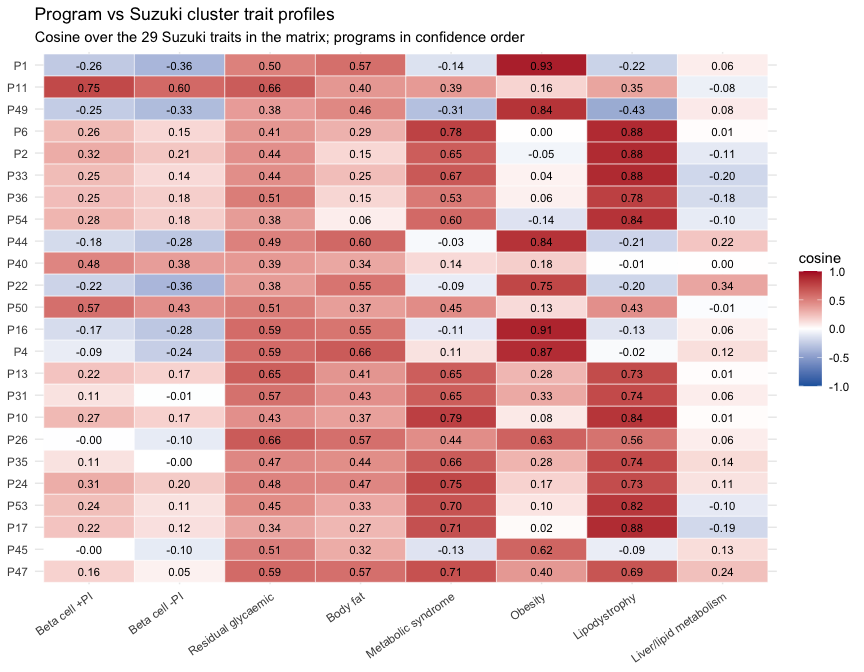

### 4e. Program summary cards

One row per high (green) or medium (orange) program, by confidence tier and then by similarity, with each child program indented under its parent:

- **effective_n_traits:** how many traits the program’s loadings are spread over (see Program confidence in Part 3).
- **specific_traits:** the top three module-specific traits.
- **tissues and pathways:** the top three loading-based hits (FDR ≤ 0.05 and R² ≥ 0.05, largest effect first; Part 3).
- **suzuki_snvs:** the Suzuki clusters of the index SNVs matched to the program’s member SNPs (4c), largest first.
- **suzuki_loci:** those SNVs’ loci (Suzuki’s names), with the clusters of the SNVs at each (×n for several SNVs), strongest loading first. Several clusters at one locus means Suzuki had several signals there that GPMap resolves as one.
- **profile_match:** the Suzuki cluster whose trait profile is closest to the program’s (4d), with the cosine.
- **genes:** the first 10 positional and QTL genes, strongest loading first. Genes in **bold** are named at a Suzuki et al. index SNV.

One card per high (green) or medium (orange) program, each child indented under its parent. Bold genes are named at a Suzuki et al. index SNV.

| program | n_snps | effective_n_traits | specific_traits | tissues | pathways | suzuki_snvs | suzuki_loci | profile_match | positional_genes | qtl_genes |
| --- | --- | --- | --- | --- | --- | --- | --- | --- | --- | --- |
| 1 | 71 | 28.64 | Qualifications: A levels/AS levels or equivalent Apolipoprotein B levels Intelligence | none | none | Obesity 38.3 Residual glycaemic 9.2 Metabolic syndrome 6.1 Body fat 5.3 Lipodystrophy 2 Beta cell -PI 1.2 Liver/lipid metabolism 1.2 Beta cell +PI 0.6 | *SEC16B*: Obesity *POC5, HMGCR, ANKDD1B*: Obesity *TFAP2B*: Body fat, Obesity *CWH43*: Obesity *GNPDA2*: Obesity *BDNF*: Beta cell -PI, Obesity *ZC3H4*: Obesity *LINGO2*: Obesity (+64 more loci) | Obesity (0.93) | **SEC16B**, **POC5**, **TFAP2B**, **GNPDA2**, **BDNF**, **ZC3H4**, **LINGO2**, **NRXN3**, **OLFM4**, **PATJ** (+62 more) | **ANKDD1B**, **POC5**, POLK, **TFAP2B**, **BDNF**, BDNF-AS, BBC3, HIF3A, SAE1, **ZC3H4** (+73 more) |
| 11 | 27 | 5.50 | Impedance of arm (left) Impedance of arm (right) Glycated haemoglobin HbA1c levels (UKB data field 30750) | none | Protein processing in endoplasmic reticulum | Residual glycaemic 7.8 Beta cell -PI 5.5 Metabolic syndrome 3.4 Beta cell +PI 3.3 Body fat 3.2 Obesity 2.2 Lipodystrophy 0.6 | *KL*: Beta cell +PI, Residual glycaemic *RN7SL232P, CDC123, CAMK1D*: Beta cell -PI, Residual glycaemic, Body fat *SSR1, RREB1*: Residual glycaemic *ZBED3*: Beta cell +PI, Body fat, Obesity *FOCAD, CDK… | Beta cell +PI (0.75) | **KL**, **CDC123**, **RREB1**, **ZBED3**, **CDKN2B**, **GLIS3**, **KCNJ11**, **ACSL1**, NEDD1, **GPSM1** (+17 more) | **CAMK1D**, **CDC123**, ENSG00000228302, ENSG00000285994, NUDT5, SEC61A2, **RREB1**, **SSR1**, PDE8B, ZBED3-AS1 (+34 more) |
| 49 | 14 | 2.28 | Comparative body size at age 10 Impedance of leg (right) Body mass index (BMI) | none | none | Obesity 8.4 Metabolic syndrome 1.9 Body fat 1.1 Residual glycaemic 0.3 Liver/lipid metabolism 0.2 | *SEC16B*: Obesity *CWH43*: Obesity *GNPDA2*: Obesity *ZC3H4*: Obesity *TFAP2B*: Body fat, Obesity *LEKR1, CCNL1*: Metabolic syndrome *DLK1, MEG3*: Obesity *MTIF3, LINC00543*: Body fat, Obesity (+5 mor… | Obesity (0.84) | **SEC16B**, **GNPDA2**, **ZC3H4**, **TFAP2B**, **LEKR1**, RTL1, **MTIF3**, **ANAPC4**, **CRTC1**, **TRIM66** (+4 more) | BBC3, HIF3A, SAE1, **ZC3H4**, **TFAP2B**, TIPARP, GTF3A, **MTIF3**, **CRTC1**, STK33 (+3 more) |
| 6 | 25 | 20.96 | Heel bone mineral density Sex hormone-binding globulin levels adjusted for BMI Leg fat-free mass (left) | none | none | Metabolic syndrome 10.3 Lipodystrophy 5.8 Residual glycaemic 4.9 Body fat 3 Obesity 1 | *GRB14, COBLL1, GALNT3*: Residual glycaemic, Body fat, Metabolic syndrome ×2, Lipodystrophy ×2 *ITGA1, ARL15*: Body fat, Metabolic syndrome *SLC22A3*: Residual glycaemic, Metabolic syndrome *ANKRD55, … | Lipodystrophy (0.88) | **COBLL1**, **ARL15**, **SLC22A3**, **ANKRD55**, BCL2, **L3MBTL3**, **INSR**, **KLF14**, **PDE3A**, ZC3H11B (+15 more) | **COBLL1**, SCN2A, ENSG00000287656, **SLC22A3**, **L3MBTL3**, **INSR**, **KLF14**, LINC00513, **GRB14**, **PDE3A** (+18 more) |
| 2 | 9 | 100.45 | Cholesteryl esters to total lipids ratio in very large VLDL Cholesterol to total lipids ratio in very large VLDL Triglyceride levels | none | Cholesterol metabolism | Lipodystrophy 2.8 Residual glycaemic 2.6 Metabolic syndrome 2 Body fat 0.7 | *MAP2K7, INSR, AC010336.1*: Lipodystrophy *GRB14, COBLL1, GALNT3*: Residual glycaemic, Metabolic syndrome, Lipodystrophy *ANKRD55, SLC38A9, AC022431.2*: Residual glycaemic, Metabolic syndrome, Lipodys… | Lipodystrophy (0.88) | MLXIPL, ANGPTL4, **COBLL1**, MAP3K1, **ANKRD55**, **CMIP**, **NFE2L3**, **KLF14**, PRKAG3 | ENSG00000274080, MLXIPL, ANGPTL4, **COBLL1**, SCN2A, C5orf67, ENSG00000270933, **KLF14**, LINC00513, WNT6 |
| ↳ 33 | 4 | 42.15 | Triglyceride levels HDL cholesterol levels Triglyceride levels (UKB data field 30870) | none | none | Residual glycaemic 1.8 Metabolic syndrome 1 Lipodystrophy 1 Body fat 0.2 | *GRB14, COBLL1, GALNT3*: Residual glycaemic, Metabolic syndrome, Lipodystrophy *GRM8, GCC1, PAX4, LEP*: Residual glycaemic *KLF14*: Body fat, Metabolic syndrome, Lipodystrophy *CMIP*: Metabolic syndro… | Lipodystrophy (0.88) | **COBLL1**, **KLF14**, **CMIP**, **ANKRD55** | **COBLL1**, SCN2A, **KLF14**, LINC00513 |
| ↳ 36 | 3 | 63.29 | none | none | none | Residual glycaemic 1.3 Metabolic syndrome 0.8 Lipodystrophy 0.8 | *ANKRD55, SLC38A9, AC022431.2*: Residual glycaemic, Metabolic syndrome, Lipodystrophy *RAB3C*: Residual glycaemic *CMIP*: Metabolic syndrome, Lipodystrophy | Lipodystrophy (0.78) | MAP3K1, **ANKRD55**, **CMIP** | C5orf67 |
| 54 | 6 | 14.99 | High density lipoprotein cholesterol levels (UKB data field 30760) Triglyceride levels Triglyceride levels (UKB data field 30870) | none | Class I MHC mediated antigen processing & presentation SARS-CoV-2 Infection Interferon gamma signaling | Residual glycaemic 2.1 Body fat 1.8 Metabolic syndrome 1.2 Lipodystrophy 0.7 Beta cell -PI 0.2 | *MHC region*: Beta cell -PI, Residual glycaemic, Body fat, Metabolic syndrome *GRM8, GCC1, PAX4, LEP*: Residual glycaemic *KLF14*: Body fat, Metabolic syndrome, Lipodystrophy *DMGDH, JMY*: Body fat *P… | Lipodystrophy (0.84) | HLA-B, **KLF14**, **DMGDH**, PRKAG3, **ANKRD55**, **NFE2L3** | ENSG00000271581, HLA-B, HLA-C, **KLF14**, LINC00513, BHMT, BHMT2, **DMGDH**, **JMY**, WNT6 (+1 more) |
| 44 | 25 | 5.12 | C-reactive protein levels C-reactive protein Trunk fat-free mass | none | none | Obesity 12.3 Beta cell -PI 2.1 Residual glycaemic 2.1 Metabolic syndrome 1.8 Body fat 1.6 Liver/lipid metabolism 1 | *ANAPC4*: Obesity *WSCD2*: Obesity *ZBTB46*: Obesity *AFF3*: Body fat, Obesity *LONRF1, RP11-252C15.1, SGCZ*: Obesity *AC007796.1*: Beta cell -PI, Body fat *RP11-98C8.1*: Residual glycaemic *MAP2K5*: … | Obesity (0.84) | **ANAPC4**, **WSCD2**, ENSG00000273154, ZGPAT, POU3F3, **SGCZ**, ZNF536, CBLN1, TSKU, **MAP2K5** (+16 more) | ARFRP1, LIME1, RTEL1, SLC2A4RG, STMN3, TNFRSF6B, **ZBTB46**, PANTR1, ENSG00000280061, ZNF536 (+32 more) |
| 40 | 3 | 12.82 | none | none | TCR signaling Generation of second messenger molecules Costimulation by the CD28 family | Metabolic syndrome 1.8 Residual glycaemic 0.8 Body fat 0.3 | *MHC region*: Residual glycaemic ×2, Body fat, Metabolic syndrome ×3 | Beta cell +PI (0.48) | HLA-DQA1, HLA-DQB1, CCHCR1 | HLA-DQA1, HLA-DRB1, HLA-DRB5, HLA-DRB6, HLA-DRB9, TNXB, ZBTB9, HLA-DQB1, C6orf15, CCHCR1 (+5 more) |
| 22 | 10 | 4.47 | C-reactive protein levels Arm fat percentage (left) Leg fat percentage (left) | Plasma | Vesicle-mediated transport Cholesterol metabolism Mitophagy - animal | Obesity 3.8 Body fat 2.7 Liver/lipid metabolism 1 Metabolic syndrome 0.6 Beta cell -PI 0.3 Residual glycaemic 0.3 Lipodystrophy 0.2 | *RN7SL836P, EML2, TOMM40, APOE, GIPR*: Liver/lipid metabolism *ZBTB46*: Obesity *RP11-505K9.4*: Body fat *ACBD4*: Body fat *MLX, LINC00910, RP11-400F19.6*: Metabolic syndrome, Obesity *ARPP21*: Obesit… | Obesity (0.75) | **APOE**, ENSG00000273154, ZGPAT, MLYCD, OSGIN1, MMS22L, **MLX**, **ARPP21**, **SEC16B**, TOMM7 (+2 more) | APOC1, **APOE**, LNCOB1, SYMPK, **TOMM40**, ZNF227, ARFRP1, LIME1, RTEL1, SLC2A4RG (+21 more) |
| 50 | 24 | 2.36 | Triglyceride levels Gamma glutamyl transpeptidase Gamma glutamyltransferase levels (UKB data field 30730) | none | none | Residual glycaemic 5.2 Metabolic syndrome 4.8 Body fat 4.5 Beta cell +PI 3 Beta cell -PI 2.5 Lipodystrophy 2.1 Obesity 0.9 | *MTNR1B*: Beta cell +PI, Beta cell -PI, Residual glycaemic *RN7SL836P, EML2, TOMM40, APOE, GIPR*: Beta cell +PI, Body fat, Metabolic syndrome, Obesity *ONECUT1, WDR72, MYO5C*: Beta cell +PI, Body fat,… | Beta cell +PI (0.57) | **MTNR1B**, **EML2**, **MYO5C**, **CLEC14A**, PFKM, SENP1, FAM234A, **AP3S2**, **DNM3**, PIGC (+16 more) | **EML2**, SNRPD2, CERNA1, **MYO5C**, ENSG00000279875, PHB1P18, SENP1, FAM234A, ANPEP, **AP3S2** (+30 more) |
| 16 | 46 | 5.51 | Red cell distribution width Calcium levels (UKB data field 30680) Pulse rate, automated reading | none | none | Obesity 18.3 Residual glycaemic 8.5 Body fat 3.9 Metabolic syndrome 3.8 Beta cell -PI 3.5 Lipodystrophy 2.3 Beta cell +PI 1.6 | *SEC16B*: Obesity *ANAPC4*: Obesity *TFAP2B*: Body fat, Obesity *AOC1*: Metabolic syndrome, Obesity, Lipodystrophy *L3MBTL3*: Metabolic syndrome *ZC3H4*: Obesity *PCSK1, CTD-2337A12.1*: Obesity *CTC-2… | Obesity (0.91) | **SEC16B**, **ANAPC4**, **TFAP2B**, **AOC1**, **L3MBTL3**, **ZC3H4**, **PCSK1**, SLC12A2, **POC5**, **GNPDA2** (+36 more) | **TFAP2B**, **AOC1**, TMEM176A, TMEM176B, **L3MBTL3**, BBC3, HIF3A, SAE1, **ZC3H4**, ARSK (+42 more) |
| 4 | 68 | 23.19 | Qualifications: A levels/AS levels or equivalent Sitting height Triglyceride levels | none | none | Obesity 25.7 Metabolic syndrome 9.4 Residual glycaemic 9.2 Body fat 8.4 Beta cell -PI 2.9 Lipodystrophy 1.9 Beta cell +PI 1.5 Liver/lipid metabolism 1 | *MDM4, CNTN2, RAB7L1, SRGAP2*: Obesity *AOC1*: Metabolic syndrome, Obesity, Lipodystrophy *CALCR*: Metabolic syndrome *SOCS2*: Residual glycaemic *L3MBTL3*: Metabolic syndrome *TRIM66, SBF2*: Residual… | Obesity (0.87) | NUCKS1, **AOC1**, CDK6, **SOCS2**, **L3MBTL3**, LMO1, **PCSK1**, SLC12A2, ELAVL2, MLXIPL (+58 more) | NUCKS1, RAB29, **AOC1**, TMEM176A, TMEM176B, CDK6, ENSG00000286742, **L3MBTL3**, LMO1, ARSK (+82 more) |
| 13 | 27 | 6.03 | Alcohol intake frequency. Low density lipoprotein cholesterol levels Pulse pressure | none | Neuroactive ligand signaling Dilated cardiomyopathy Cadherin signaling | Obesity 8.5 Residual glycaemic 5.1 Metabolic syndrome 4.7 Body fat 4.1 Beta cell -PI 1.5 Lipodystrophy 1.2 | *TCF7L2*: Body fat *GRM8, GCC1, PAX4, LEP*: Residual glycaemic *KLF14*: Body fat, Metabolic syndrome, Lipodystrophy *GP2*: Residual glycaemic, Obesity *SAT2, SLC16A11, SLC16A13*: Beta cell -PI, Metabo… | Lipodystrophy (0.73) | ADRB1, **KLF14**, PDILT, PHF23, SLC39A8, **ANKRD55**, **CEP68**, MAP3K1, NRIP1, **ADH1B** (+18 more) | ADRB1, **TCF7L2**, **KLF14**, LINC00513, ACADVL, CLDN7, CTDNEP1, DLG4, DVL2, ELP5 (+53 more) |
| 31 | 28 | 2.68 | High blood pressure (UKB data field 6150) (Firth correction) High blood pressure (UKB data field 6150) (SPA correction) Impedance of arm (right) | none | none | Metabolic syndrome 6.6 Residual glycaemic 5.8 Lipodystrophy 5.8 Obesity 4.4 Body fat 3 Beta cell -PI 0.3 Beta cell +PI 0.1 | *GRB14, COBLL1, GALNT3*: Residual glycaemic, Metabolic syndrome, Lipodystrophy *LEKR1, CCNL1*: Metabolic syndrome *ERLIN1, RNU2-43P*: Obesity *RP3-523E19.2*: Body fat, Metabolic syndrome *CYTL1*: Lipo… | Lipodystrophy (0.74) | **COBLL1**, **LEKR1**, **ERLIN1**, GSTA1, **CYTL1**, **SLC22A3**, ADRB1, **EBF1**, CDCA2, PPARA (+19 more) | **COBLL1**, SCN2A, TIPARP, BLOC1S2, CHUK-DT, CWF19L1, **ERLIN1**, KAZALD1, PHB1P9, SNORA12 (+34 more) |
| 10 | 24 | 7.02 | Mean corpuscular haemoglobin Triglyceride levels Reticulocyte count | none | TGF-beta signaling pathway | Metabolic syndrome 7.7 Residual glycaemic 4.8 Body fat 4.2 Beta cell -PI 3.2 Lipodystrophy 1.8 Obesity 0.3 | *PTGFRN, FAM46C*: Beta cell -PI *TFRC*: Residual glycaemic *GRB14, COBLL1, GALNT3*: Residual glycaemic, Metabolic syndrome, Lipodystrophy *HSPA4*: Metabolic syndrome *KCNJ12*: Body fat *ABO, LINC00094… | Lipodystrophy (0.84) | TENT5C, **TFRC**, MLXIPL, **SKI**, **COBLL1**, **HSPA4**, **KCNJ12**, BRD3, BRD3OS, **INSR** (+15 more) | TENT5C, TENT5C-DT, **TFRC**, ENSG00000274080, MLXIPL, FAAP20, **SKI**, **COBLL1**, SCN2A, **HSPA4** (+24 more) |
| 26 | 6 | 20.33 | HDL cholesterol Triglyceride levels | Kidney Cortex Brain Amygdala | Non-small cell lung cancer Chronic myeloid leukemia Melanoma | Obesity 2 Lipodystrophy 1.7 Metabolic syndrome 1.2 Body fat 0.7 Residual glycaemic 0.3 | *POC5, HMGCR, ANKDD1B*: Obesity *HMBS*: Obesity *JAZF1*: Body fat, Metabolic syndrome *LOC646588, NFE2L3*: Body fat, Metabolic syndrome, Lipodystrophy *FAM13A*: Lipodystrophy *PDE3A*: Residual glycaem… | Residual glycaemic (0.66) | **POC5**, **HMBS**, **NFE2L3**, **FAM13A**, **PDE3A**, **CMIP** | **ANKDD1B**, **POC5**, POLK, H2AX, **HMBS**, HYOU1, SLC37A4, VPS11, ENSG00000270933, **FAM13A** (+1 more) |
| 35 | 32 | 5.07 | Mean platelet volume Sex hormone-binding globulin levels adjusted for BMI Red cell distribution width | Liver | Signaling by NOTCH Cytokine-cytokine receptor interaction Diseases of signal transduction by growth factor receptors and second messengers | Metabolic syndrome 10.3 Residual glycaemic 6.1 Obesity 5.2 Lipodystrophy 4.8 Body fat 4.1 Liver/lipid metabolism 1 Beta cell -PI 0.5 | *MACF1*: Residual glycaemic, Obesity *LEKR1, CCNL1*: Metabolic syndrome *ERLIN1, RNU2-43P*: Obesity *RP11-713M15.2, RP11-3G20.1*: Residual glycaemic, Body fat *PNPLA3*: Liver/lipid metabolism *GRB14, … | Lipodystrophy (0.74) | PABPC4, **LEKR1**, **ERLIN1**, SNTB1, **PNPLA3**, **COBLL1**, CDCA2, **HMBS**, SLC12A2, **CHD4** (+24 more) | BMP8A, HEYL, **MACF1**, OXCT2P1, PABPC4, PABPC4-AS1, PPIEL, TIPARP, BLOC1S2, CHUK-DT (+64 more) |
| 24 | 25 | 2.50 | Leg fat-free mass (left) Heel bone mineral density | none | none | Metabolic syndrome 11.8 Residual glycaemic 4.7 Lipodystrophy 4 Body fat 2.4 Obesity 1.8 Beta cell +PI 0.3 | *ANKRD55, SLC38A9, AC022431.2*: Residual glycaemic *DNM3*: Lipodystrophy *LEKR1, CCNL1*: Metabolic syndrome *FAM13A*: Lipodystrophy *SLC22A3*: Residual glycaemic, Metabolic syndrome *EBF2*: Residual g… | Metabolic syndrome (0.75) | **ANKRD55**, **DNM3**, PIGC, **LEKR1**, **FAM13A**, **SLC22A3**, CDCA2, **FGFR4**, BCL2, **CYTL1** (+16 more) | **DNM3**, PIGC, TIPARP, **FAM13A**, ENSG00000287656, **SLC22A3**, **FGFR4**, RAB24, **ABCA1**, TMEM38B (+25 more) |
| 53 | 7 | 55.64 | High density lipoprotein cholesterol levels (UKB data field 30760) HDL cholesterol HDL cholesterol levels | none | Signaling by NOTCH Diseases of signal transduction by growth factor receptors and second messengers Cytokine-cytokine receptor interaction | Residual glycaemic 2.8 Metabolic syndrome 2.1 Body fat 0.9 Lipodystrophy 0.8 Obesity 0.5 | *MACF1*: Residual glycaemic, Obesity *ANKRD55, SLC38A9, AC022431.2*: Residual glycaemic *CMIP*: Metabolic syndrome, Lipodystrophy *L3MBTL3*: Metabolic syndrome *GRM8, GCC1, PAX4, LEP*: Residual glycae… | Lipodystrophy (0.82) | PABPC4, **ANKRD55**, **CMIP**, **L3MBTL3**, **KLF14**, GSTA1, **TFRC** | BMP8A, HEYL, **MACF1**, OXCT2P1, PABPC4, PABPC4-AS1, PPIEL, **L3MBTL3**, **KLF14**, LINC00513 (+7 more) |
| 17 | 3 | 58.63 | Triglyceride levels (UKB data field 30870) | Plasma | Cholesterol metabolism | Lipodystrophy 1.2 Body fat 1 Residual glycaemic 0.5 Metabolic syndrome 0.2 | *MAP2K7, INSR, AC010336.1*: Lipodystrophy *GRB14, COBLL1, GALNT3*: Residual glycaemic, Metabolic syndrome, Lipodystrophy *DMGDH, JMY*: Body fat | Lipodystrophy (0.88) | ANGPTL4, **COBLL1**, **DMGDH** | ANGPTL4, **COBLL1**, SCN2A, BHMT, BHMT2, **DMGDH**, **JMY** |
| 45 | 11 | 7.41 | Lung function (FEV1/FVC) Appendicular lean mass FEV1 | none | none | Residual glycaemic 4.5 Obesity 2.3 Metabolic syndrome 1.3 Lipodystrophy 0.3 Beta cell -PI 0.2 Body fat 0.2 | *ZBTB46*: Obesity *AC114788.2*: Residual glycaemic *RN7SL232P, CDC123, CAMK1D*: Beta cell -PI, Residual glycaemic, Body fat *HHIP*: Metabolic syndrome *ANAPC4*: Obesity *AOC1*: Metabolic syndrome, Obe… | Obesity (0.62) | HTR4, ENSG00000273154, ZGPAT, TWIST2, **CDC123**, **SKI**, **HHIP**, **ANAPC4**, **AOC1**, **SOCS2** (+2 more) | ARFRP1, LIME1, RTEL1, SLC2A4RG, STMN3, TNFRSF6B, **ZBTB46**, **CAMK1D**, **CDC123**, ENSG00000228302 (+10 more) |
| 47 | 34 | 2.81 | Red cell distribution width IGF 1 (UKB data field 30770) Aspartate aminotransferase levels | none | RHO GTPase cycle Mitophagy - animal | Metabolic syndrome 10.2 Residual glycaemic 6.2 Lipodystrophy 5.2 Obesity 4.8 Body fat 3.3 Beta cell -PI 2.1 Beta cell +PI 1.3 Liver/lipid metabolism 1 | *PNPLA3*: Liver/lipid metabolism *ERLIN1, RNU2-43P*: Obesity *SSR1, RREB1*: Residual glycaemic *PDGFC*: Lipodystrophy *CTC-228N24.3*: Metabolic syndrome *MACF1*: Residual glycaemic, Obesity *RP11-505K… | Metabolic syndrome (0.71) | **PNPLA3**, **ERLIN1**, **RREB1**, **PDGFC**, SLC12A2, PABPC4, MLYCD, OSGIN1, **SEC16B**, **IGF2** (+27 more) | **PNPLA3**, SAMM50, BLOC1S2, CHUK-DT, CWF19L1, **ERLIN1**, KAZALD1, PHB1P9, SNORA12, **PDGFC** (+62 more) |

### 4f. Matching programs to Suzuki clusters

This section is written by hand from the results above, reading each program’s card (4e) with its Suzuki SNV counts (4c) and trait-profile similarity (4d). The calls are:

- **clear:** the SNV counts favour the cluster (q ≤ 0.05) *and* the trait profile is closest to it or to a cluster it cannot be told apart from;
- **partial:** only one of the two supports the cluster, or the program sits between two similar clusters;
- **none:** no consistent match.

Three pairs of clusters have similar profiles over the traits GPMap has (4d): Beta cell +PI and −PI (cosine 0.92), Metabolic syndrome and Lipodystrophy (0.81), and Body fat and Obesity (0.73). A program is not expected to separate the members of a pair, so a call can name both.

The program numbers and statistics below come from one render. The next chunk checks each call against the current results and prints a warning if a program has changed, so the text cannot silently go stale.

Hand-written match of each high (green) or medium (orange) program to Suzuki’s clusters

| program | suzuki_cluster | call | reading |
| --- | --- | --- | --- |
| 1 | Obesity | clear | Largest program. Most of its matched SNVs are Obesity (SEC16B, TFAP2B, GNPDA2, BDNF, FTO) and its profile is closest to Obesity. Its most specific traits (education, intelligence, apolipoprotein B) ar… |
| 11 | Beta cell +PI / Beta cell -PI | clear | The only beta-cell program. HbA1c is its most specific glycaemic trait, it carries CDC123/CAMK1D, CDKN2A/B and KCNJ11/ABCC8, and its SNVs lean to Beta cell -PI while its profile is closest to Beta cel… |
| 49 | Obesity | clear | A compact BMI core: BMI, body size at age 10 and impedance. Most of its SNPs are also in P1, including SEC16B, GNPDA2 and TFAP2B. |
| 6 | Lipodystrophy / Metabolic syndrome | clear | GRB14/COBLL1, INSR and ARL15; SHBG, heel bone density and lean mass. Lipodystrophy SNVs are the most over-represented and Metabolic syndrome SNVs the most numerous; the profile is closest to Lipodystr… |
| 2 | Lipodystrophy | clear | A lipid (VLDL, triglyceride) program at the insulin-resistance loci (INSR, GRB14/COBLL1, ANKRD55, CMIP). P33 and P36 sit inside it. |
| ↳ 33 | Lipodystrophy / Metabolic syndrome | partial | Sub-program of P2 with 4 SNPs: triglycerides and HDL. Too few SNPs for the SNV counts; the profile matches Lipodystrophy. |
| ↳ 36 | Lipodystrophy / Metabolic syndrome | partial | Sub-program of P33 with 3 SNPs. Too few SNPs for the SNV counts; the profile matches Lipodystrophy. |
| 54 | Lipodystrophy / Metabolic syndrome | partial | HDL and triglycerides with KLF14; the profile matches Lipodystrophy but its 6 SNPs show no cluster preference. |
| 44 | Obesity | clear | Obesity SNVs and an Obesity profile, with C-reactive protein as its most specific trait: an inflammation-flavoured obesity program. |
| 40 | none | none | Three SNPs in the MHC region with immune pathways; not a Suzuki-like program. |
| 22 | Obesity / Body fat | partial | CRP and limb fat percentage; the profile is closest to Obesity, but the SNV counts show no preference. |
| 50 | Beta cell +PI / Beta cell -PI | partial | MTNR1B, a fasting-glucose locus, with triglycerides and GGT. Its profile is closest to Beta cell +PI, but the SNV preference is not significant. |
| 16 | Obesity | clear | Obesity SNVs (SEC16B, TFAP2B, GNPDA2, PCSK1) and an Obesity profile; shares many SNPs with P1. |
| 4 | Obesity | clear | Second large Obesity program (education, sitting height, triglycerides); shares many SNPs with P1. |
| 13 | none | none | Mixed: alcohol intake, LDL and pulse pressure. The profile sits between Lipodystrophy and Metabolic syndrome, but the SNVs show no preference. |
| 31 | Lipodystrophy / Metabolic syndrome | clear | Blood pressure and impedance at GRB14/COBLL1, EBF1 and CYTL1; Lipodystrophy SNVs over-represented and a Lipodystrophy profile. |
| 10 | Metabolic syndrome / Lipodystrophy | clear | Red-cell traits and triglycerides at INSR, ABO and GRB14/COBLL1; Metabolic syndrome SNVs over-represented, Lipodystrophy profile. |
| 26 | none | none | Six SNPs, HDL and triglycerides; no SNV preference and no clear profile. |
| 35 | Metabolic syndrome / Lipodystrophy | clear | Platelet and red-cell traits with SHBG; Metabolic syndrome SNVs over-represented, Lipodystrophy profile. |
| 24 | Metabolic syndrome | clear | Lean mass and heel bone density; the strongest Metabolic syndrome SNV enrichment, and its profile is closest to Metabolic syndrome. |
| 53 | Lipodystrophy / Metabolic syndrome | partial | HDL cholesterol; a Lipodystrophy profile but no significant SNV preference. |
| 17 | Lipodystrophy / Metabolic syndrome | partial | Three SNPs, triglycerides; a Lipodystrophy profile, too few SNPs for the SNV counts. |
| 45 | none | none | Lung function and lean mass; no SNV preference, and the profile is only weakly Obesity-like. |
| 47 | Lipodystrophy / Metabolic syndrome | clear | IGF-1, AST and red-cell traits at PNPLA3 and INS/IGF2; Lipodystrophy SNVs over-represented, Metabolic syndrome profile. |

**Against the expectations.**

- **Obesity is recovered clearly and repeatedly** (P1, P49, P44, P16, P4). P1, P4 and P16 share many SNPs, and P49 is a BMI core that sits mostly inside P1.
- **Lipodystrophy and Metabolic syndrome are recovered together.** Many programs sit at the insulin-resistance loci (GRB14/COBLL1, INSR, ANKRD55, CMIP, KLF14). The SNV counts pull some towards Lipodystrophy (P2, P6, P31, P47) and others towards Metabolic syndrome (P10, P24, P35). The trait profiles cannot separate the two, because Suzuki’s own profiles are close over these traits.
- **Beta cell: one joint program (P11), as expected.** It carries markers of both beta-cell clusters, and neither the SNVs nor the profile split them.
- **Body fat merges into Obesity, as expected.** No program prefers Body fat SNVs; they are spread over the Obesity programs.
- **Residual glycaemic, the largest cluster, has no program of its own.** Its SNVs are spread across programs (4c), which fits its role as a catch-all.
- **Liver/lipid metabolism is not recovered**, as expected with 3 signals.
- **Tissues give little support to the expectations.** Only four high or medium programs have a loading-based tissue hit (4e). P35 (Metabolic syndrome / Lipodystrophy) is enriched in liver, P22 and P17 in plasma, and P26 (no match) in kidney cortex and brain amygdala. No Lipodystrophy-like program is enriched in adipose, and no Obesity program in brain.

## Part 5: Candidate trait pairs for a multi-trait analysis

This part is documentation only; nothing here is run. Each pair runs the upload against one partner trait in the multi-trait investigation. The Suzuki clusters predict which shared programs the pair should show and in which direction:

- **concordant:** the T2D risk allele raises the partner trait;
- **antagonistic:** the T2D risk allele lowers it.

| Partner trait | GPMap id | N | Coloc groups | Clusters it should separate | Expected pattern |
| --- | --- | --- | --- | --- | --- |
| Body mass index | 1992 | 532,396 | 992 | Obesity vs beta-cell | Obesity programs shared and concordant; Beta cell ±PI programs T2D-specific |
| Triglyceride levels | 1631 | 437,532 | 587 | Lipodystrophy, Metabolic syndrome, Liver/lipid | Lipodystrophy and Metabolic syndrome concordant; TM6SF2-type liver loci antagonistic |
| HDL cholesterol levels | 1630 | 400,754 | 735 | Lipodystrophy, Obesity, Metabolic syndrome | Antagonistic sharing (T2D risk lowers HDL) |
| Waist-to-hip ratio adjusted for BMI | 1653 | 458,349 | 478 | Lipodystrophy vs Obesity | Lipodystrophy concordant, with BMI removed |
| Waist-hip ratio | 1994 | 502,773 | 550 | Lipodystrophy, Obesity, Metabolic syndrome | Concordant for all three |
| Haemoglobin A1c levels | 1640 | 437,749 | 838 | Beta-cell, Residual glycaemic | Glycaemic clusters shared; obesity/lipid clusters weaker |
| Fasting glucose | 913 | 200,622 | 95 | Beta-cell, Residual glycaemic | As HbA1c, but sparse in GPMap |
| Body fat percentage | 2581 | 401,772 | 671 | Body fat, Obesity vs Lipodystrophy | Body fat and Obesity concordant; Lipodystrophy antagonistic |
| Alanine aminotransferase / GGT | 1642 / 1634 | ≈437,700 | 449 / 702 | Liver/lipid, Metabolic syndrome | Liver-fat loci concordant |
| Coronary artery disease | 2475 | 352,063 | 64 | Obesity vs Beta cell +PI | Obesity concordant; Beta cell +PI antagonistic (Suzuki’s polygenic-score result) |
| Type 2 diabetes (GPMap native) | 114 | 655,666 | 178 | none | Replication pair: programs should correspond one to one |

**Caveat: sample overlap.** UK Biobank, and for several traits FinnGen and the Million Veteran Program, contribute to both the T2DGGI EUR meta-analysis and most partner GWAS. Correlated sampling error then inflates apparent sharing between the two traits. Sharing that is weak or confined to a single locus should be read with this in mind.

**Untested.** The multi-trait vignette has not yet been run with an upload GUID as one of its traits. A first run would look like this:

```r
rmarkdown::render(
  "vignettes/investigation-multitrait-programs.Rmd",
  params = list(
    api = "production",
    trait_ids = c("c6d2e20f-6ece-d093-78ee-37534547c466", 1992)
  ),
  output_file = "investigation-multitrait-programs-t2dggi-bmi.html"
)
```